# Data Processing

Research questions: what are the most important determinants towards UBI?

individual Characteristics

- age group
- gender
- Employment status
- Left-right self placement
- Members of Union
- Net Household income
- Feeling about income
- Education

Control group2: belief or preferences

- Economic Individualism
- Economic fairness
- Prefereces for redistribution

Control group3: welfare attitudes

- Preventing poverty
- Promoting equality
- Increasing laziness
- Burden or businesses
- Strain on the economy
- Supporting for targeting
- Welfare chauvisism

Control group4: Media bais

- Media bais X right_wing
- Media bais X left_wing
- Increasing laziness X right_wing

Contry level

- support for UBI
- net income inequality
- unemployment ratw
- social expenditure
- social protection
- material deprivation
- welfare universalism index

```python
# import packages

import csv
import datetime
import numpy as np
import pandas as pd
import seaborn as sns
import matplotlib.pyplot as plt
from sklearn.preprocessing import LabelEncoder
from sklearn.feature_extraction.text import TfidfVectorizer
from sklearn.neighbors import KNeighborsClassifier
from sklearn.naive_bayes import GaussianNB, MultinomialNB
from sklearn.model_selection import cross_val_score, train_test_split
from sklearn.linear_model import LogisticRegression
from sklearn.model_selection import cross_val_score
from sklearn.metrics import confusion_matrix, plot_confusion_matrix
from sklearn.metrics import roc_curve, auc, plot_roc_curve
from sklearn.preprocessing import label_binarize
from sklearn.model_selection import cross_val_score, validation_curve, train_test_split
import warnings
warnings.filterwarnings("ignore")
```

```python
# import dataset
# import data
df_ess8= pd.read_csv('/ESS-Data-Wizard-subset-2023-04-09/ESS-Data-Wizard-subset-2023-04-09.csv')
df_ess8
```

|  | name | essround | edition | proddate | idno | cntry | dweight | pspwght | pweight | anweight | ... | iphlppl | ipsuces | ipstrgv | ipadvnt | ipbhprp | iprspot | iplylfr | impenv | imptrad | impfun |
| --- | --- | --- | --- | --- | --- | --- | --- | --- | --- | --- | --- | --- | --- | --- | --- | --- | --- | --- | --- | --- | --- |
| 0 | ESS8e02_2 | 8 | 2.2 | 10.12.2020 | 1 | AT | 0.611677 | 1.178495 | 0.370393 | 0.436506 | ... | 1 | 2 | 6 | 3 | 6 | 1 | 1 | 1 | 6 | 3 |
| 1 | ESS8e02_2 | 8 | 2.2 | 10.12.2020 | 2 | AT | 1.223354 | 0.899471 | 0.370393 | 0.333158 | ... | 3 | 3 | 4 | 5 | 5 | 2 | 2 | 2 | 5 | 5 |
| 2 | ESS8e02_2 | 8 | 2.2 | 10.12.2020 | 4 | AT | 0.389058 | 0.315753 | 0.370393 | 0.116953 | ... | 3 | 6 | 1 | 6 | 3 | 3 | 1 | 2 | 2 | 3 |
| 3 | ESS8e02_2 | 8 | 2.2 | 10.12.2020 | 6 | AT | 0.642594 | 0.472467 | 0.370393 | 0.174999 | ... | 3 | 3 | 2 | 3 | 4 | 2 | 2 | 3 | 2 | 2 |
| 4 | ESS8e02_2 | 8 | 2.2 | 10.12.2020 | 10 | AT | 3.432402 | 2.246706 | 0.370393 | 0.832164 | ... | 1 | 3 | 4 | 5 | 2 | 3 | 1 | 1 | 4 | 1 |
| ... | ... | ... | ... | ... | ... | ... | ... | ... | ... | ... | ... | ... | ... | ... | ... | ... | ... | ... | ... | ... | ... |
| 44382 | ESS8e02_2 | 8 | 2.2 | 10.12.2020 | 1303 | SI | 1.000000 | 0.835442 | 0.134491 | 0.112359 | ... | 1 | 1 | 1 | 1 | 2 | 2 | 1 | 2 | 1 | 1 |
| 44383 | ESS8e02_2 | 8 | 2.2 | 10.12.2020 | 1304 | SI | 1.000000 | 0.756328 | 0.134491 | 0.101719 | ... | 1 | 1 | 1 | 4 | 1 | 2 | 1 | 1 | 1 | 2 |
| 44384 | ESS8e02_2 | 8 | 2.2 | 10.12.2020 | 1305 | SI | 1.000000 | 0.856172 | 0.134491 | 0.115147 | ... | 2 | 2 | 2 | 4 | 1 | 1 | 2 | 1 | 2 | 5 |
| 44385 | ESS8e02_2 | 8 | 2.2 | 10.12.2020 | 1306 | SI | 1.000000 | 0.756328 | 0.134491 | 0.101719 | ... | 1 | 1 | 1 | 2 | 3 | 1 | 3 | 2 | 4 | 1 |
| 44386 | ESS8e02_2 | 8 | 2.2 | 10.12.2020 | 1307 | SI | 1.000000 | 0.802472 | 0.134491 | 0.107925 | ... | 2 | 4 | 4 | 2 | 2 | 3 | 3 | 4 | 3 | 3 |

44387 rows × 65 columns

```python
print("Current column names:")
print(df_ess8.columns)
```

```
Current column names:
Index(['name', 'essround', 'edition', 'proddate', 'idno', 'cntry', 'dweight',
       'pspwght', 'pweight', 'anweight', 'nwspol', 'netusoft', 'netustm',
       'ppltrst', 'pplfair', 'pplhlp', 'prtdgcl', 'lrscale', 'imbgeco',
       'imueclt', 'imwbcnt', 'happy', 'health', 'brncntr', 'dfincac',
       'smdfslv', 'sbstrec', 'sbprvpv', 'sbeqsoc', 'sblazy', 'sblwcoa',
       'imsclbn', 'bnlwinc', 'basinc', 'lkuemp', 'gndr', 'agea', 'chldhm',
       'edulvlb', 'uempla', 'uemp3m', 'hinctnta', 'hincfel', 'uemplap',
       'ipcrtiv', 'imprich', 'ipeqopt', 'ipshabt', 'impsafe', 'impdiff',
       'ipfrule', 'ipudrst', 'ipmodst', 'ipgdtim', 'impfree', 'iphlppl',
       'ipsuces', 'ipstrgv', 'ipadvnt', 'ipbhprp', 'iprspot', 'iplylfr',
       'impenv', 'imptrad', 'impfun'],
      dtype='object')
```

### Basic Human Value

```python
df = df_ess8
df['v1'] = np.where(df['ipcrtiv'] <= 6, 7 - df['ipcrtiv'], df['ipcrtiv'])
df['v2'] = np.where(df['imprich'] <= 6, 7 - df['imprich'], df['imprich'])
df['v3'] = np.where(df['ipeqopt'] <= 6, 7 - df['ipeqopt'], df['ipeqopt'])
df['v4'] = np.where(df['ipshabt'] <= 6, 7 - df['ipshabt'], df['ipshabt'])
df['v5'] = np.where(df['impsafe'] <= 6, 7 - df['impsafe'], df['impsafe'])
df['v6'] = np.where(df['impdiff'] <= 6, 7 - df['impdiff'], df['impdiff'])
df['v7'] = np.where(df['ipfrule'] <= 6, 7 - df['ipfrule'], df['ipfrule'])
df['v8'] = np.where(df['ipudrst'] <= 6, 7 - df['ipudrst'], df['ipudrst'])
df['v9'] = np.where(df['ipmodst'] <= 6, 7 - df['ipmodst'], df['ipmodst'])
df['v10'] = np.where(df['ipgdtim'] <= 6, 7 - df['ipgdtim'], df['ipgdtim'])
df['v11'] = np.where(df['impfree'] <= 6, 7 - df['impfree'], df['impfree'])
df['v12'] = np.where(df['iphlppl'] <= 6, 7 - df['iphlppl'], df['iphlppl'])
df['v13'] = np.where(df['ipsuces'] <= 6, 7 - df['ipsuces'], df['ipsuces'])
df['v14'] = np.where(df['ipstrgv'] <= 6, 7 - df['ipstrgv'], df['ipstrgv'])
df['v15'] = np.where(df['ipadvnt'] <= 6, 7 - df['ipadvnt'], df['ipadvnt'])
df['v16'] = np.where(df['ipbhprp'] <= 6, 7 - df['ipbhprp'], df['ipbhprp'])
df['v17'] = np.where(df['iprspot'] <= 6, 7 - df['iprspot'], df['iprspot'])
df['v18'] = np.where(df['iplylfr'] <= 6, 7 - df['iplylfr'], df['iplylfr'])
df['v19'] = np.where(df['impenv'] <= 6, 7 - df['impenv'], df['impenv'])
df['v20'] = np.where(df['imptrad'] <= 6, 7 - df['imptrad'], df['imptrad'])
df['v21'] = np.where(df['impfun'] <= 6, 7 - df['impfun'], df['impfun'])


# Calculating each individual's mean score over all 21 value items
valvars = ['v1', 'v2', 'v3', 'v4', 'v5', 'v6', 'v7', 'v8', 'v9', 'v10', 'v11', 'v12', 'v13', 'v14', 'v15', 'v16', 'v17', 'v18', 'v19', 'v20', 'v21']
df['mrat'] = df[valvars].mean(axis=1)

# Calculating each value
df['security'] = (df[['v5', 'v14']].mean(axis=1) - df['mrat'])
df['conformity'] = (df[['v7', 'v16']].mean(axis=1) - df['mrat'])
df['tradition'] = (df[['v9', 'v20']].mean(axis=1) - df['mrat'])
df['benevolence'] = (df[['v12', 'v18']].mean(axis=1) - df['mrat'])
df['universalism'] = (df[['v3', 'v8', 'v19']].mean(axis=1) - df['mrat'])
df['selfdirection'] = (df[['v1', 'v11']].mean(axis=1) - df['mrat'])
df['stimulation'] = (df[['v6', 'v15']].mean(axis=1) - df['mrat'])
df['hedonism'] = (df[['v10', 'v21']].mean(axis=1) - df['mrat'])
df['achievement'] = (df[['v4', 'v13']].mean(axis=1) - df['mrat'])
df['power'] = (df[['v2', 'v17']].mean(axis=1) - df['mrat'])

# Value items for each value
df['equality'] = df['v3'] - df['mrat']
df['broadmind'] = df['v8'] - df['mrat']
df['environ'] = df['v19'] - df['mrat']
df['helpful'] = df['v12'] - df['mrat']
df['loyal'] = df['v18'] - df['mrat']
df['wealth'] = df['v2'] - df['mrat']
df['socpower'] = df['v17'] - df['mrat']
df['capable'] = df['v4'] - df['mrat']
df['success'] = df['v13'] - df['mrat']

# Reorder columns
df= df[['achievement', 'hedonism', 'stimulation', 'selfdirection', 'universalism', 'benevolence', 'tradition', 'conformity', 'security', 'power']]

# Select the columns of interest
cols = ['achievement', 'hedonism', 'stimulation', 'selfdirection', 'universalism', 'benevolence', 'tradition', 'conformity', 'security', 'power']
df= df[cols]

# Remove missing values
df.dropna(inplace=True)

# Calculate the mean of each column
mean_values = df.mean()

df['self-enhancement'] = df['achievement'] + df['power']
df['openness to change'] = df['hedonism'] + df['stimulation'] + df['selfdirection']
df['conservation'] = df['security'] + df['conformity'] + df['tradition']
df['self-transcendence'] = df['universalism'] + df['benevolence']
```

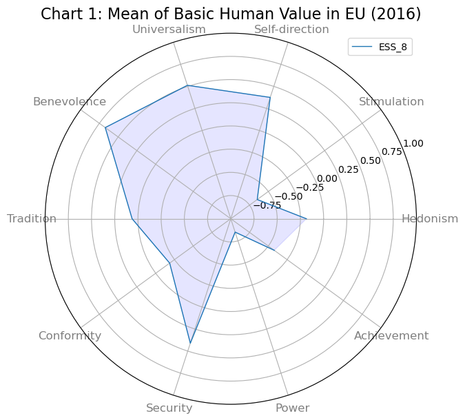

```python
# Number of variables
categories = 10

# Set the angle for each axis
angles = np.linspace(0, 2*np.pi, categories, endpoint=False)

values = [df['hedonism'].mean(), df['stimulation'].mean(), df['selfdirection'].mean(), df['universalism'].mean(), df['benevolence'].mean(), df['tradition'].mean(), df['conformity'].mean(), df['security'].mean(), df['power'].mean(), df['achievement'].mean()]

# Plot the radar chart
fig = plt.figure(figsize=(7,7))
ax = fig.add_subplot(111, polar=True)

# Set the limits for the chart
plt.ylim(-1, 1)

# Add labels for each axis
plt.xticks(angles, ['Hedonism', 'Stimulation', 'Self-direction', 'Universalism', 'Benevolence', 'Tradition', 'Conformity', 'Security', 'Power','Achievement'], color='grey', size=12)

# Plot the data on the chart
ax.plot(angles, values, linewidth=1, linestyle='solid', label='ESS_8')
ax.fill(angles, values, 'b', alpha=0.1, edgecolor='blue')

# Add a title to the chart
plt.title("Chart 1: Mean of Basic Human Value in EU (2016)", size=16)

# Add a legend to the chart
plt.legend(loc='best')

# Show the chart
plt.show()
```

```python
df
```

|  | achievement | hedonism | stimulation | selfdirection | universalism | benevolence | tradition | conformity | security | power | self-enhancement | openness to change | conservation | self-transcendence |
| --- | --- | --- | --- | --- | --- | --- | --- | --- | --- | --- | --- | --- | --- | --- |
| 0 | 0.904762 | -0.595238 | -0.095238 | 0.404762 | 1.904762 | 1.904762 | -1.095238 | -2.595238 | -1.095238 | -0.595238 | 0.309524 | -0.285714 | -4.785714 | 3.809524 |
| 1 | 0.571429 | -0.428571 | -0.428571 | 1.071429 | 1.238095 | 1.071429 | -0.928571 | -1.428571 | -0.928571 | -0.428571 | 0.142857 | 0.214286 | -3.285714 | 2.309524 |
| 2 | -1.904762 | 0.595238 | -2.904762 | 0.595238 | 1.095238 | 1.095238 | 0.595238 | -0.904762 | 2.095238 | -0.904762 | -2.809524 | -1.714286 | 1.785714 | 2.190476 |
| 3 | -0.071429 | 0.428571 | -0.571429 | 0.428571 | 0.095238 | -0.071429 | 0.428571 | -1.071429 | 0.428571 | -0.071429 | -0.142857 | 0.285714 | -0.214286 | 0.023810 |
| 4 | -0.928571 | 1.571429 | -1.428571 | 0.571429 | 0.904762 | 1.571429 | 0.071429 | -0.928571 | -0.928571 | -0.928571 | -1.857143 | 0.714286 | -1.785714 | 2.476190 |
| ... | ... | ... | ... | ... | ... | ... | ... | ... | ... | ... | ... | ... | ... | ... |
| 44382 | 0.214286 | 0.714286 | 0.714286 | 0.714286 | -1.285714 | 0.714286 | 0.214286 | -1.785714 | 0.714286 | -0.285714 | -0.071429 | 2.142857 | -0.857143 | -0.571429 |
| 44383 | 0.404762 | -0.595238 | -1.595238 | 0.904762 | 0.238095 | 0.904762 | -0.095238 | 0.404762 | 0.404762 | -1.095238 | -0.690476 | -1.285714 | 0.714286 | 1.142857 |
| 44384 | 0.595238 | -2.404762 | -0.904762 | 0.595238 | 0.761905 | 0.095238 | 0.595238 | 1.095238 | 0.595238 | -1.404762 | -0.809524 | -2.714286 | 2.285714 | 0.857143 |
| 44385 | 0.500000 | 1.000000 | 0.500000 | 0.500000 | 0.000000 | 0.000000 | -1.000000 | -2.000000 | 0.500000 | 0.000000 | 0.500000 | 2.000000 | -2.500000 | 0.000000 |
| 44386 | -0.166667 | 0.333333 | 0.833333 | 0.833333 | -1.000000 | 0.833333 | 0.333333 | -0.166667 | -0.666667 | -0.666667 | -0.833333 | 2.000000 | -0.500000 | -0.166667 |

44387 rows × 14 columns

```python
df_ess8['self-enhancement'] = df_ess8['achievement'] + df_ess8['power']
df_ess8['openness to change'] = df_ess8['hedonism'] + df_ess8['stimulation'] + df_ess8['selfdirection']
df_ess8['conservation'] = df_ess8['security'] + df_ess8['conformity'] + df_ess8['tradition']
df_ess8['self-transcendence'] = df_ess8['universalism'] + df_ess8['benevolence']
```

### Social trust, Poltical Specturm and Media Bias

```python
# News about politics and current affairs, watching, reading or listening, in minutes

to_hours = lambda x: x / 60 if x not in [7777, 8888, 9999] else None

# create a new column 'political_news_hour' by applying the lambda function to 'nwspol'

# how many hours spend on watching the news
df_ess8['political_news_hour'] = df_ess8['nwspol'].apply(to_hours)

# Most people can be trusted or you can't be too careful, 0 = you can't be too careful, 10 = most people can be trusted
df_ess8['trust_in_people'] = np.where((df_ess8['ppltrst'] >= 0) & (df_ess8['ppltrst'] <= 10), df_ess8['ppltrst'], np.nan)

# Most people try to take advantage of you, or try to be fair, 0 = most people try to take advantage of me, most people try to be fair
df_ess8['fair_in_people'] = np.where((df_ess8['pplfair'] >= 0) & (df_ess8['pplfair'] <= 10), df_ess8['pplfair'], np.nan)

# Most of the time people helpful or mostly looking out for themselves, 0 = people mostly look for themselves, 10 = people mosrtly try to be helpful

df_ess8['helpful_in_people'] = np.where((df_ess8['pplhlp'] >= 0) & (df_ess8['pplhlp'] <= 10), df_ess8['pplhlp'], np.nan)

# How close to party, 1 = very close, 4 = not close at all

df_ess8['distance_to_party'] = np.where((df_ess8['prtdgcl'] >= 1) & (df_ess8['prtdgcl'] <= 4), df_ess8['prtdgcl'], np.nan)

# Placement on left right scale, 0 = left, 10 = right

df_ess8['left_on_scale'] = np.where((df_ess8['lrscale'] >= 0) & (df_ess8['lrscale'] <= 10), df_ess8['lrscale'], np.nan)
```

### Economics Belief, Preferences and Welfare Attitudes

```python
# Large differences in income acceptable to reward talents and efforts, 1 = agree strongly, 5 = disagree strongly
df_ess8['economics_individulism'] = np.where((df_ess8['dfincac'] >= 1) & (df_ess8['dfincac'] <= 5), df_ess8['dfincac'], np.nan)

# For fair society, differences in standard of living should be small, 1 = agree strongly, 5 = disagree strongly
df_ess8['economics_fainess'] = np.where((df_ess8['smdfslv'] >= 1) & (df_ess8['smdfslv'] <= 5), df_ess8['smdfslv'], np.nan)

# Social benefits/services place too great strain on economy, 1 = agree strongly, 5 = disagree strongly
df_ess8['strain_on_the_economy'] = np.where((df_ess8['sbstrec'] >= 1) & (df_ess8['sbstrec'] <= 5), df_ess8['sbstrec'], np.nan)

# Social benefits/services prevent widespread poverty, 1 = agree strongly, 5 = disagree strongly
df_ess8['preventing_poverty'] = np.where((df_ess8['sbprvpv'] >= 1) & (df_ess8['sbprvpv'] <= 5), df_ess8['sbprvpv'], np.nan)

# Social benefits/services lead to a more equal society, 1 = agree strongly, 5 = disagree strongly
df_ess8['promote_equality'] = np.where((df_ess8['sbeqsoc'] >= 1) & (df_ess8['sbeqsoc'] <= 5), df_ess8['sbeqsoc'], np.nan)

# Social benefits/services make people lazy, 1 = agree strongly, 5 = disagree strongly
df_ess8['increasing_laziness'] = np.where((df_ess8['sblazy'] >= 1) & (df_ess8['sblazy'] <= 5), df_ess8['sblazy'], np.nan)

# Social benefits/services make people less willing care for one another, 1 = agree strongly, 5 = disagree strongly
df_ess8['less_caring'] = np.where((df_ess8['sblwcoa'] >= 1) & (df_ess8['sblwcoa'] <= 5), df_ess8['sblwcoa'], np.nan)

# W5, 1 = Immediately on arrival, 5 = They should never get the same rights
df_ess8['welfare_chauvinism'] = np.where((df_ess8['imsclbn'] >= 1) & (df_ess8['imsclbn'] <= 5), df_ess8['imsclbn'], np.nan)

# Social benefits only for people with lowest incomes, 1 = stronly against, 4 = strongly in favour
df_ess8['support_for_targeting'] = np.where((df_ess8['bnlwinc'] >= 1) & (df_ess8['bnlwinc'] <= 4), df_ess8['bnlwinc'], np.nan)

# Against or In favour of a basic income scheme, 1 = strongly against, 4 = Strongly in favour
df_ess8['support_for_ubi'] = np.where((df_ess8['basinc'] >= 1) & (df_ess8['basinc'] <= 4), df_ess8['basinc'], np.nan)
```

### Individual Characteristics

##### Unemployment, History of Unemployment, History of Unemployment

```python
# Doing last 7 days: unemployed, actively looking for job, 0 = not marked, 1 = marked
df_ess8['is_unemployed'] = np.where(df_ess8['uempla'] == 1, 1, np.where(df_ess8['uempla'] == 0, 0, np.nan))

# Ever unemployed and seeking work for a period more than three months, 1 = yes, 2 = no

df_ess8['was_unemployed_exceed_3months'] = np.where(df_ess8['uemp3m'] == 1, 1, np.where(df_ess8['uemp3m'] == 2, 0, np.nan))

# how likely unemployed and looking for work next 12 months, 1 = Not at all likely, 4 = very likely, 55 = not working/not looking for work/never worked
df_ess8['likely_to_become_unemployed'] = np.where((df_ess8['lkuemp'] >= 1) & (df_ess8['lkuemp'] <= 4), df_ess8['lkuemp'], np.nan)
```

```python
# how happy are you, 0 = extremely unhappy, 10 = extremely happy
df_ess8['happy_level'] = np.where((df_ess8['happy'] >= 1) & (df_ess8['happy'] <= 5), df_ess8['happy'], np.nan)


# subjective general health, 1= very good, 5 = very bad
df_ess8['healthy_level'] = np.where((df_ess8['health'] >= 1) & (df_ess8['health'] <= 5), df_ess8['health'], np.nan)


# born in country, 1 = yes, 0 = no

df_ess8['is_born_in_country'] = np.where(df_ess8['brncntr'] == 1, 1, np.where(df_ess8['brncntr'] == 0, 0, np.nan))


# gender, 1 = male, 2 = female
df_ess8['is_female'] = np.where(df_ess8['gndr'] == 2, 1, np.where(df_ess8['gndr'] == 1, 0, np.nan))

# Age of respondent, calculated
current_year = datetime.datetime.now().year
df_ess8['age_group'] = (df_ess8['agea'] // 10) * 10


# Highest level of education
df_ess8['is_bachelor'] = np.where((df_ess8['edulvlb'] >= 0) & (df_ess8['edulvlb'] <= 800), np.where(df_ess8['edulvlb'] >= 610, 1, 0), np.nan)



# Household's total net income, all sources
df_ess8['income_group'] = np.where((df_ess8['hinctnta'] >= 1) & (df_ess8['hinctnta'] <= 10), df_ess8['hinctnta'], np.nan)


# Feeling about household's income nowadays, 1 = Living comfortably on present income, 4 = Very difficult on present income
df_ess8['difficult_on_present_income'] = np.where((df_ess8['hincfel'] >= 1) & (df_ess8['hincfel'] <= 4), df_ess8['hincfel'], np.nan)


# Children living at home or not, 1 = respondent lives with children at household grid, 2 = does not
df_ess8['live_with_child']  = np.where((df_ess8['chldhm'] >= 1) & (df_ess8['chldhm'] <= 2), df_ess8['chldhm'], np.nan)
```

```python
df_1= df_ess8[[
    'idno','cntry','security', 'conformity', 'tradition', 'benevolence', 'universalism',
    'selfdirection', 'stimulation', 'hedonism', 'achievement', 'power', 'self-enhancement', 'openness to change', 'conservation',
    'self-transcendence', 'political_news_hour', 'trust_in_people', 'fair_in_people',
    'helpful_in_people', 'distance_to_party', 'left_on_scale', 'economics_individulism',
    'economics_fainess', 'strain_on_the_economy', 'preventing_poverty', 'promote_equality',
    'increasing_laziness', 'less_caring', 'welfare_chauvinism', 'support_for_targeting',
    'support_for_ubi', 'happy_level', 'healthy_level', 'is_born_in_country', 'is_female',
    'age_group', 'is_bachelor', 'income_group', 'difficult_on_present_income', 'live_with_child',
    'is_unemployed', 'was_unemployed_exceed_3months', 'likely_to_become_unemployed'
]]
```

```python
human_value_df = df_1[['security', 'conformity', 'tradition', 'benevolence', 'universalism',
    'selfdirection', 'stimulation', 'hedonism', 'achievement', 'power', 'self-enhancement', 'openness to change', 'conservation',
    'self-transcendence']]
```

```python
variable_df = df_1[['political_news_hour', 'trust_in_people', 'fair_in_people',
    'helpful_in_people', 'distance_to_party', 'left_on_scale', 'economics_individulism',
    'economics_fainess', 'strain_on_the_economy', 'preventing_poverty', 'promote_equality',
    'increasing_laziness', 'less_caring', 'welfare_chauvinism', 'support_for_targeting',
    'support_for_ubi', 'happy_level', 'healthy_level', 'is_born_in_country', 'is_female',
    'age_group', 'is_bachelor', 'income_group', 'difficult_on_present_income', 'live_with_child',
    'is_unemployed', 'was_unemployed_exceed_3months', 'likely_to_become_unemployed']]
```

```python
variable_descriptions = {
    'political_news_hour': 'News about politics and current affairs, watching, reading or listening, in hours',
    'trust_in_people': 'Most people can be trusted or you can not be too careful, 0 = you can not be too careful, 10 = most people can be trusted',
    'fair_in_people': 'Most people try to take advantage of you, or try to be fair, 0 = most people try to take advantage of me, most people try to be fair',
    'helpful_in_people': 'Most of the time people helpful or mostly looking out for themselves, 0 = people mostly look for themselves, 10 = people mosrtly try to be helpful',
    'distance_to_party': 'How close to party, 1 = very close, 4 = not close at all',
    'left_on_scale': 'Placement on left right scale, 0 = left, 10 = right',
    'economics_individulism': 'Large differences in income acceptable to reward talents and efforts, 1 = agree strongly, 5 = disagree strongly',
    'economics_fainess': 'For fair society, differences in standard of living should be small, 1 = agree strongly, 5 = disagree strongly',
    'strain_on_the_economy': 'Social benefits/services place too great strain on economy, 1 = agree strongly, 5 = disagree strongly',
    'preventing_poverty': 'Social benefits/services prevent widespread poverty, 1 = agree strongly, 5 = disagree strongly',
    'promote_equality': 'Social benefits/services lead to a more equal society, 1 = agree strongly, 5 = disagree strongly',
    'increasing_laziness': 'Social benefits/services make people lazy, 1 = agree strongly, 5 = disagree strongly',
    'less_caring':'Social benefits/services make people lazy, 1 = agree strongly, 5 = disagree strongly',
    'welfare_chauvinism': 'When should immigrants obtain rights to social benefits/services, 1 = Immediately on arrival, 5 = They should never get the same rights',
    'support_for_targeting': ' Social benefits only for people with lowest incomes, 1 = stronly against, 4 = strongly in favour',
    'support_for_ubi': 'Against or In favour of a basic income scheme, 1 = strongly against, 4 = Strongly in favour',
    'happy_level': 'how happy are you, 0 = extremely unhappy, 10 = extremely happy',
    'healthy_level': 'subjective general health, 1= very good, 5 = very bad',
    'is_born_in_country': 'born in country, 1 = yes, 0 = no',
    'is_female': 'gender, 1 = male, 2 = female',
    'age_group': ' Age of respondent, calculated',
    'is_bachelor': 'Highest level of education is bachelor',
    'income_group': 'Household total net income, all sources on a scale of 1-10',
    'live_with_child': 'Children living at home or not, 1 = respondent lives with children at household grid, 2 = does not',
    'satisfy_current_inc': 'Feeling about households income nowadays, 1 = Living comfortably on present income, 4 = Very difficult on present income',
    'is_unemployed': 'Doing last 7 days: unemployed, actively looking for job, 0 = not marked, 1 = marked ',
    'was_unemployed_exceed_3months': 'Ever unemployed and seeking work for a period more than three months, 1 = yes, 2 = no',
    'likely_to_become_unemployed': 'how likely unemployed and looking for work next 12 months, 1 = Not at all likely, 4 = very likely, 55 = not working/not looking for work/never worked'
    }
```

```python
variable_labels = {
    'political_news_hour': 'hours spent on watching news',
    'trust_in_people': 'level of trust in people',
    'fair_in_people': 'perception of fairness in people',
    'helpful_in_people': 'perception of helpfulness in people',
    'distance_to_party': 'distance to party',
    'left_on_scale': 'left on the political spectrum',
    'economics_individulism': 'attitude towards economic individualism',
    'economics_fainess': 'attitude towards economic fairness',
    'strain_on_the_economy': 'welfare put strain on the economy',
    'preventing_poverty': 'welfare prevent poverty',
    'promote_equality': 'welfare promote equality',
    'increasing_laziness': 'welfare increase laziness',
    'less_caring': 'welfare result in less caring',
    'welfare_chauvinism': 'welfare chauvinism',
    'support_for_targeting': 'welfare should target pool',
    'support_for_ubi': 'level of support for UBI',
    'happy_level': 'level of happiness',
    'healthy_level': 'level of health',
    'is_born_in_country': 'citizenship in country',
    'is_female': 'gender',
    'age_group': 'age group',
    'is_bachelor': 'bachelor degree',
    'income_group': 'income group in 10 decile',
    'difficult_on_present_income': 'satisfaction with current income',
    'live_with_child': 'child in household',
    'is_unemployed': 'currently unemployed',
    'was_unemployed_exceed_3months': 'has a history of 3 months unemployment',
    'likely_to_become_unemployed': 'anxiety about becoming unemployed'
}
```

```python
# set the column names to the variable names
variable_df.columns = list(variable_labels.keys())

# create a new DataFrame with the variable labels and descriptions
desc_df = pd.DataFrame({'Variable Name': variable_df.columns,
                        'Variable Label': list(variable_labels.values()),
                        'Description': list(variable_descriptions.values())})

# calculate the descriptive statistics for each variable and add them to the description DataFrame
desc_df['Missing_value'] = variable_df.isna().sum().values
desc_df['Mean'] = variable_df.mean().values
desc_df['Med.'] = variable_df.median().values
desc_df['Std.'] = variable_df.std().values
desc_df['Min.'] = variable_df.min().values
desc_df['Max.'] = variable_df.max().values
desc_df['Dev.'] = variable_df.max().values - variable_df.min().values

# Set the display options to increase the maximum column width
pd.set_option("display.html.table_schema", False)

# add left padding to each cell in the DataFrame
desc_df = desc_df.style.set_properties(**{'text-align': 'left', 'padding-left': '10px'})

# display the description table
desc_df
```

|  | Variable Name | Variable Label | Description | Missing_value | Mean | Med. | Std. | Min. | Max. | Dev. |
| --- | --- | --- | --- | --- | --- | --- | --- | --- | --- | --- |
| 0 | political_news_hour | hours spent on watching news | News about politics and current affairs, watching, reading or listening, in hours | 524 | 1.423815 | 1.000000 | 2.279981 | 0.000000 | 23.800000 | 23.800000 |
| 1 | trust_in_people | level of trust in people | Most people can be trusted or you can not be too careful, 0 = you can not be too careful, 10 = most people can be trusted | 115 | 5.268928 | 5.000000 | 2.365384 | 0.000000 | 10.000000 | 10.000000 |
| 2 | fair_in_people | perception of fairness in people | Most people try to take advantage of you, or try to be fair, 0 = most people try to take advantage of me, most people try to be fair | 315 | 5.805727 | 6.000000 | 2.181923 | 0.000000 | 10.000000 | 10.000000 |
| 3 | helpful_in_people | perception of helpfulness in people | Most of the time people helpful or mostly looking out for themselves, 0 = people mostly look for themselves, 10 = people mosrtly try to be helpful | 176 | 5.210332 | 5.000000 | 2.253054 | 0.000000 | 10.000000 | 10.000000 |
| 4 | distance_to_party | distance to party | How close to party, 1 = very close, 4 = not close at all | 25320 | 2.154036 | 2.000000 | 0.649322 | 1.000000 | 4.000000 | 3.000000 |
| 5 | left_on_scale | left on the political spectrum | Placement on left right scale, 0 = left, 10 = right | 5804 | 5.156649 | 5.000000 | 2.238901 | 0.000000 | 10.000000 | 10.000000 |
| 6 | economics_individulism | attitude towards economic individualism | Large differences in income acceptable to reward talents and efforts, 1 = agree strongly, 5 = disagree strongly | 867 | 2.982422 | 3.000000 | 1.132926 | 1.000000 | 5.000000 | 4.000000 |
| 7 | economics_fainess | attitude towards economic fairness | For fair society, differences in standard of living should be small, 1 = agree strongly, 5 = disagree strongly | 796 | 2.392673 | 2.000000 | 0.951588 | 1.000000 | 5.000000 | 4.000000 |
| 8 | strain_on_the_economy | welfare put strain on the economy | Social benefits/services place too great strain on economy, 1 = agree strongly, 5 = disagree strongly | 2163 | 3.034649 | 3.000000 | 1.054989 | 1.000000 | 5.000000 | 4.000000 |
| 9 | preventing_poverty | welfare prevent poverty | Social benefits/services prevent widespread poverty, 1 = agree strongly, 5 = disagree strongly | 1340 | 2.584524 | 2.000000 | 0.996721 | 1.000000 | 5.000000 | 4.000000 |
| 10 | promote_equality | welfare promote equality | Social benefits/services lead to a more equal society, 1 = agree strongly, 5 = disagree strongly | 1493 | 2.736140 | 3.000000 | 1.010121 | 1.000000 | 5.000000 | 4.000000 |
| 11 | increasing_laziness | welfare increase laziness | Social benefits/services make people lazy, 1 = agree strongly, 5 = disagree strongly | 1031 | 2.914891 | 3.000000 | 1.123202 | 1.000000 | 5.000000 | 4.000000 |
| 12 | less_caring | welfare result in less caring | Social benefits/services make people lazy, 1 = agree strongly, 5 = disagree strongly | 1546 | 3.031115 | 3.000000 | 1.075310 | 1.000000 | 5.000000 | 4.000000 |
| 13 | welfare_chauvinism | welfare chauvinism | When should immigrants obtain rights to social benefits/services, 1 = Immediately on arrival, 5 = They should never get the same rights | 1984 | 3.190765 | 3.000000 | 1.050289 | 1.000000 | 5.000000 | 4.000000 |
| 14 | support_for_targeting | welfare should target pool | Social benefits only for people with lowest incomes, 1 = stronly against, 4 = strongly in favour | 2562 | 2.383957 | 2.000000 | 0.818870 | 1.000000 | 4.000000 | 3.000000 |
| 15 | support_for_ubi | level of support for UBI | Against or In favour of a basic income scheme, 1 = strongly against, 4 = Strongly in favour | 3795 | 2.514239 | 3.000000 | 0.821866 | 1.000000 | 4.000000 | 3.000000 |
| 16 | happy_level | level of happiness | how happy are you, 0 = extremely unhappy, 10 = extremely happy | 37884 | 4.192373 | 5.000000 | 1.090516 | 1.000000 | 5.000000 | 4.000000 |
| 17 | healthy_level | level of health | subjective general health, 1= very good, 5 = very bad | 59 | 2.199219 | 2.000000 | 0.921266 | 1.000000 | 5.000000 | 4.000000 |
| 18 | is_born_in_country | citizenship in country | born in country, 1 = yes, 0 = no | 4716 | 1.000000 | 1.000000 | 0.000000 | 1.000000 | 1.000000 | 0.000000 |
| 19 | is_female | gender | gender, 1 = male, 2 = female | 9 | 0.526184 | 1.000000 | 0.499320 | 0.000000 | 1.000000 | 1.000000 |
| 20 | age_group | age group | Age of respondent, calculated | 0 | 47.887895 | 40.000000 | 58.879176 | 10.000000 | 990.000000 | 980.000000 |
| 21 | is_bachelor | bachelor degree | Highest level of education is bachelor | 217 | 0.243899 | 0.000000 | 0.429437 | 0.000000 | 1.000000 | 1.000000 |
| 22 | income_group | income group in 10 decile | Household total net income, all sources on a scale of 1-10 | 7942 | 5.189244 | 5.000000 | 2.733617 | 1.000000 | 10.000000 | 9.000000 |
| 23 | difficult_on_present_income | satisfaction with current income | Children living at home or not, 1 = respondent lives with children at household grid, 2 = does not | 524 | 1.947997 | 2.000000 | 0.833233 | 1.000000 | 4.000000 | 3.000000 |
| 24 | live_with_child | child in household | Feeling about households income nowadays, 1 = Living comfortably on present income, 4 = Very difficult on present income | 11 | 1.649270 | 2.000000 | 0.477204 | 1.000000 | 2.000000 | 1.000000 |
| 25 | is_unemployed | currently unemployed | Doing last 7 days: unemployed, actively looking for job, 0 = not marked, 1 = marked | 0 | 0.039786 | 0.000000 | 0.195459 | 0.000000 | 1.000000 | 1.000000 |
| 26 | was_unemployed_exceed_3months | has a history of 3 months unemployment | Ever unemployed and seeking work for a period more than three months, 1 = yes, 2 = no | 218 | 0.282212 | 0.000000 | 0.450081 | 0.000000 | 1.000000 | 1.000000 |
| 27 | likely_to_become_unemployed | anxiety about becoming unemployed | how likely unemployed and looking for work next 12 months, 1 = Not at all likely, 4 = very likely, 55 = not working/not looking for work/never worked | 10287 | 1.820381 | 2.000000 | 0.944000 | 1.000000 | 4.000000 | 3.000000 |

```python
import dataframe_image as dfi
dfi.export(desc_df, 'tabel 1 sec.png')
```

```
/Applications/Google Chrome.app/Contents/MacOS/Google Chrome
/Applications/Google Chrome.app/Contents/MacOS/Google Chrome
/Applications/Google Chrome.app/Contents/MacOS/Google Chrome
/Applications/Google Chrome.app/Contents/MacOS/Google Chrome
```

```python
# Define the variable categories
panel1_vars = ['political_news_hour', 'trust_in_people', 'fair_in_people']
panel2_vars = ['distance_to_party', 'left_on_scale', 'economics_individulism', 'economics_fainess']
panel3_vars = ['strain_on_the_economy', 'preventing_poverty', 'promote_equality', 'increasing_laziness', 'less_caring', 'welfare_chauvinism', 'support_for_targeting', 'support_for_ubi']
panel4_vars = ['happy_level', 'healthy_level']
panel5_vars = ['is_born_in_country', 'is_female', 'age_group', 'is_bachelor', 'income_group', 'difficult_on_present_income', 'live_with_child', 'is_unemployed', 'was_unemployed_exceed_3months', 'likely_to_become_unemployed']

# Create separate dataframes for each panel
panel1_df = df_1[panel1_vars].describe().T[['count', 'mean', '50%', 'std', 'min', 'max']].reset_index().rename(columns={'index': 'Variable Name', 'mean': 'Mean', '50%': 'Med.', 'std': 'Std.', 'min': 'Min.', 'max': 'Max.', 'count': 'Missing_value'})
panel1_df['Variable Label'] = panel1_df['Variable Name'].map({'political_news_hour': 'hours spent on watching news',
                                                             'trust_in_people': 'level of trust in people',
                                                             'fair_in_people': 'perception of fairness in people'})
panel1_df['Description'] = panel1_df['Variable Label'] + '. ' + 'Panel 1: Social trust and media'
panel1_df['Dev.'] = (panel1_df['Max.'] - panel1_df['Min.']) / panel1_df['Std.']
panel1_df = panel1_df[['Variable Name', 'Variable Label', 'Description', 'Missing_value', 'Mean', 'Med.', 'Std.', 'Min.', 'Max.', 'Dev.']]

panel2_df = df_1[panel2_vars].describe().T[['count', 'mean', '50%', 'std', 'min', 'max']].reset_index().rename(columns={'index': 'Variable Name', 'mean': 'Mean', '50%': 'Med.', 'std': 'Std.', 'min': 'Min.', 'max': 'Max.', 'count': 'Missing_value'})
panel2_df['Variable Label'] = panel2_df['Variable Name'].map({'distance_to_party': 'distance to party',
                                                             'left_on_scale': 'left on the political spectrum',
                                                             'economics_individulism': 'attitude towards economic individualism',
                                                             'economics_fainess': 'attitude towards economic fairness'})
panel2_df['Description'] = panel2_df['Variable Label'] + '. ' + 'Panel 2: Political attitudes'
panel2_df['Dev.'] = (panel2_df['Max.'] - panel2_df['Min.']) / panel2_df['Std.']
panel2_df = panel2_df[['Variable Name', 'Variable Label', 'Description', 'Missing_value', 'Mean', 'Med.', 'Std.', 'Min.', 'Max.', 'Dev.']]

panel3_df = df_1[panel3_vars].describe().T[['count', 'mean', '50%', 'std', 'min', 'max']].reset_index().rename(columns={'index': 'Variable Name', 'mean': 'Mean', '50%': 'Med.', 'std': 'Std.', 'min': 'Min.', 'max': 'Max.', 'count': 'Missing_value'})

panel3_df['Variable Label'] = panel3_df['Variable Name'].map({'strain_on_the_economy': 'welfare put strain on the economy',
                                                             'preventing_poverty': 'welfare prevent poverty',
                                                             'promote_equality': 'welfare promote equality',
                                                             'increasing_laziness': 'welfare increase laziness',
                                                             'less_caring': 'welfare result in less caring',
                                                             'welfare_chauvinism': 'welfare chauvinism',
                                                             'support_for_targeting': 'welfare should target pool',
                                                             'support_for_ubi': 'level of support for UBI'})
panel3_df['Description'] = panel3_df['Variable Label'] + '. ' + 'Panel 3: Attitudes towards welfare policies'
panel3_df['Dev.'] = (panel3_df['Max.'] - panel3_df['Min.']) / panel3_df['Std.']
panel3_df = panel3_df[['Variable Name', 'Variable Label', 'Description', 'Missing_value', 'Mean', 'Med.', 'Std.', 'Min.', 'Max.', 'Dev.']]

panel4_df = df_1[panel4_vars].describe().T[['count', 'mean', '50%', 'std', 'min', 'max']].reset_index().rename(columns={'index': 'Variable Name', 'mean': 'Mean', '50%': 'Med.', 'std': 'Std.', 'min': 'Min.', 'max': 'Max.', 'count': 'Missing_value'})
panel4_df['Variable Label'] = panel4_df['Variable Name'].map({'happy_level': 'level of happiness',
                                                             'healthy_level': 'level of health'})
panel4_df['Description'] = panel4_df['Variable Label'] + '. ' + 'Panel 4: Health and well-being'
panel4_df['Dev.'] = (panel4_df['Max.'] - panel4_df['Min.']) / panel4_df['Std.']
panel4_df = panel4_df[['Variable Name', 'Variable Label', 'Description', 'Missing_value', 'Mean', 'Med.', 'Std.', 'Min.', 'Max.', 'Dev.']]

panel5_df = df_1[panel5_vars].describe().T[['count', 'mean', '50%', 'std', 'min', 'max']].reset_index().rename(columns={'index': 'Variable Name', 'mean': 'Mean', '50%': 'Med.', 'std': 'Std.', 'min': 'Min.', 'max': 'Max.', 'count': 'Missing_value'})
panel5_df['Variable Label'] = panel5_df['Variable Name'].map({'is_born_in_country': 'citizenship in country',
                                                             'is_female': 'gender',
                                                             'age_group': 'age group',
                                                             'is_bachelor': 'bachelor degree',
                                                             'income_group': 'income group in 10 decile',
                                                             'difficult_on_present_income': 'satisfaction with current income',
                                                             'live_with_child': 'child in household',
                                                             'is_unemployed': 'currently unemployed',
                                                             'was_unemployed_exceed_3months': 'has a history of 3 months unemployment',
                                                             'likely_to_become_unemployed': 'anxiety about becoming unemployed'})
panel5_df['Description'] = panel5_df['Variable Label'] + '. ' + 'Panel 5: Demographic information and economic status'
panel5_df['Dev.'] = (panel5_df['Max.'] - panel5_df['Min.']) / panel5_df['Std.']
panel5_df = panel5_df[['Variable Name', 'Variable Label', 'Description', 'Missing_value', 'Mean', 'Med.','Std.', 'Min.', 'Max.', 'Dev.']]

# Merge dataframes for each panel into a single dataframe
df_panels = pd.concat([panel1_df, panel2_df, panel3_df, panel4_df, panel5_df], ignore_index=True)

# Create a dictionary to map the variable names to their respective sections
variable_sections = {
    'political_news_hour': 'Panel 1: Social trust and media',
    'trust_in_people': 'Panel 1: Social trust and media',
    'fair_in_people': 'Panel 1: Social trust and media',
    'distance_to_party': 'Panel 2: Political attitudes',
    'left_on_scale': 'Panel 2: Political attitudes',
    'economics_individulism': 'Panel 2: Political attitudes',
    'economics_fainess': 'Panel 2: Political attitudes',
    'strain_on_the_economy': 'Panel 3: Attitudes towards welfare policies',
    'preventing_poverty': 'Panel 3: Attitudes towards welfare policies',
    'promote_equality': 'Panel 3: Attitudes towards welfare policies',
    'increasing_laziness': 'Panel 3: Attitudes towards welfare policies',
    'less_caring': 'Panel 3: Attitudes towards welfare policies',
    'welfare_chauvinism': 'Panel 3: Attitudes towards welfare policies',
    'support_for_targeting': 'Panel 3: Attitudes towards welfare policies',
    'support_for_ubi': 'Panel 3: Attitudes towards welfare policies',
    'happy_level': 'Panel 4: Health and well-being',
    'healthy_level': 'Panel 4: Health and well-being',
    'is_born_in_country': 'Panel 5: Demographic information and economic status',
    'is_female': 'Panel 5: Demographic information and economic status',
    'age_group': 'Panel 5: Demographic information and economic status',
    'is_bachelor': 'Panel 5: Demographic information and economic status',
    'income_group': 'Panel 5: Demographic information and economic status',
    'difficult_on_present_income': 'Panel 5: Demographic information and economic status',
    'live_with_child': 'Panel 5: Demographic information and economic status',
    'is_unemployed': 'Panel 5: Demographic information and economic status',
    'was_unemployed_exceed_3months': 'Panel 5: Demographic information and economic status',
    'likely_to_become_unemployed': 'Panel 5: Demographic information and economic status'
}

# Add a section column to the dataframe based on the dictionary mapping
df_panels['Section'] = df_panels['Variable Name'].map(variable_sections)

# Reorder the columns
df_panels = df_panels[['Section', 'Variable Name', 'Variable Label', 'Description', 'Missing_value', 'Mean', 'Med.', 'Std.', 'Min.', 'Max.', 'Dev.']]

# Print the dataframe
print(df_panels)
```

```
                                              Section  \
0                     Panel 1: Social trust and media
1                     Panel 1: Social trust and media
2                     Panel 1: Social trust and media
3                        Panel 2: Political attitudes
4                        Panel 2: Political attitudes
5                        Panel 2: Political attitudes
6                        Panel 2: Political attitudes
7         Panel 3: Attitudes towards welfare policies
8         Panel 3: Attitudes towards welfare policies
9         Panel 3: Attitudes towards welfare policies
10        Panel 3: Attitudes towards welfare policies
11        Panel 3: Attitudes towards welfare policies
12        Panel 3: Attitudes towards welfare policies
13        Panel 3: Attitudes towards welfare policies
```

[output cut: 100 more lines]

```python
import dataframe_image as dfi
dfi.export(df_panels, 'tabel 1 sec.png')
```

```
/Applications/Google Chrome.app/Contents/MacOS/Google Chrome
/Applications/Google Chrome.app/Contents/MacOS/Google Chrome
/Applications/Google Chrome.app/Contents/MacOS/Google Chrome
```

```python
# set the column names to the variable names
variable_df.columns = list(variable_labels.keys())

# create a new DataFrame with the variable labels and descriptions
desc_df = pd.DataFrame({'Variable Name': variable_df.columns,
                        'Variable Label': list(variable_labels.values()),
                        'Description': list(variable_descriptions.values())})

# calculate the descriptive statistics for each variable and add them to the description DataFrame
desc_df['Missing_value'] = variable_df.isna().sum().values
desc_df['Mean'] = variable_df.mean().values
desc_df['Med.'] = variable_df.median().values
desc_df['Std.'] = variable_df.std().values
desc_df['Min.'] = variable_df.min().values
desc_df['Max.'] = variable_df.max().values
desc_df['Dev.'] = variable_df.max().values - variable_df.min().values

# Set the display options to increase the maximum column width
pd.set_option('display.max_colwidth', 50)

# add left padding to each cell in the DataFrame
desc_df = desc_df.style.set_properties(**{'text-align': 'left', 'padding-left': '10px'})

# display the description table
desc_df
```

|  | Variable Name | Variable Label | Description | Missing_value | Mean | Med. | Std. | Min. | Max. | Dev. |
| --- | --- | --- | --- | --- | --- | --- | --- | --- | --- | --- |
| 0 | political_news_hour | hours spent on watching news | News about politics and current affairs, watching, reading or listening, in hours | 524 | 1.423815 | 1.000000 | 2.279981 | 0.000000 | 23.800000 | 23.800000 |
| 1 | trust_in_people | level of trust in people | Most people can be trusted or you can not be too careful, 0 = you can not be too careful, 10 = most people can be trusted | 115 | 5.268928 | 5.000000 | 2.365384 | 0.000000 | 10.000000 | 10.000000 |
| 2 | fair_in_people | perception of fairness in people | Most people try to take advantage of you, or try to be fair, 0 = most people try to take advantage of me, most people try to be fair | 315 | 5.805727 | 6.000000 | 2.181923 | 0.000000 | 10.000000 | 10.000000 |
| 3 | helpful_in_people | perception of helpfulness in people | Most of the time people helpful or mostly looking out for themselves, 0 = people mostly look for themselves, 10 = people mosrtly try to be helpful | 176 | 5.210332 | 5.000000 | 2.253054 | 0.000000 | 10.000000 | 10.000000 |
| 4 | distance_to_party | distance to party | How close to party, 1 = very close, 4 = not close at all | 25320 | 2.154036 | 2.000000 | 0.649322 | 1.000000 | 4.000000 | 3.000000 |
| 5 | left_on_scale | left on the political spectrum | Placement on left right scale, 0 = left, 10 = right | 5804 | 5.156649 | 5.000000 | 2.238901 | 0.000000 | 10.000000 | 10.000000 |
| 6 | economics_individulism | attitude towards economic individualism | Large differences in income acceptable to reward talents and efforts, 1 = agree strongly, 5 = disagree strongly | 867 | 2.982422 | 3.000000 | 1.132926 | 1.000000 | 5.000000 | 4.000000 |
| 7 | economics_fainess | attitude towards economic fairness | For fair society, differences in standard of living should be small, 1 = agree strongly, 5 = disagree strongly | 796 | 2.392673 | 2.000000 | 0.951588 | 1.000000 | 5.000000 | 4.000000 |
| 8 | strain_on_the_economy | welfare put strain on the economy | Social benefits/services place too great strain on economy, 1 = agree strongly, 5 = disagree strongly | 2163 | 3.034649 | 3.000000 | 1.054989 | 1.000000 | 5.000000 | 4.000000 |
| 9 | preventing_poverty | welfare prevent poverty | Social benefits/services prevent widespread poverty, 1 = agree strongly, 5 = disagree strongly | 1340 | 2.584524 | 2.000000 | 0.996721 | 1.000000 | 5.000000 | 4.000000 |
| 10 | promote_equality | welfare promote equality | Social benefits/services lead to a more equal society, 1 = agree strongly, 5 = disagree strongly | 1493 | 2.736140 | 3.000000 | 1.010121 | 1.000000 | 5.000000 | 4.000000 |
| 11 | increasing_laziness | welfare increase laziness | Social benefits/services make people lazy, 1 = agree strongly, 5 = disagree strongly | 1031 | 2.914891 | 3.000000 | 1.123202 | 1.000000 | 5.000000 | 4.000000 |
| 12 | less_caring | welfare result in less caring | Social benefits/services make people lazy, 1 = agree strongly, 5 = disagree strongly | 1546 | 3.031115 | 3.000000 | 1.075310 | 1.000000 | 5.000000 | 4.000000 |
| 13 | welfare_chauvinism | welfare chauvinism | When should immigrants obtain rights to social benefits/services, 1 = Immediately on arrival, 5 = They should never get the same rights | 1984 | 3.190765 | 3.000000 | 1.050289 | 1.000000 | 5.000000 | 4.000000 |
| 14 | support_for_targeting | welfare should target pool | Social benefits only for people with lowest incomes, 1 = stronly against, 4 = strongly in favour | 2562 | 2.383957 | 2.000000 | 0.818870 | 1.000000 | 4.000000 | 3.000000 |
| 15 | support_for_ubi | level of support for UBI | Against or In favour of a basic income scheme, 1 = strongly against, 4 = Strongly in favour | 3795 | 2.514239 | 3.000000 | 0.821866 | 1.000000 | 4.000000 | 3.000000 |
| 16 | happy_level | level of happiness | how happy are you, 0 = extremely unhappy, 10 = extremely happy | 37884 | 4.192373 | 5.000000 | 1.090516 | 1.000000 | 5.000000 | 4.000000 |
| 17 | healthy_level | level of health | subjective general health, 1= very good, 5 = very bad | 59 | 2.199219 | 2.000000 | 0.921266 | 1.000000 | 5.000000 | 4.000000 |
| 18 | is_born_in_country | citizenship in country | born in country, 1 = yes, 0 = no | 4716 | 1.000000 | 1.000000 | 0.000000 | 1.000000 | 1.000000 | 0.000000 |
| 19 | is_female | gender | gender, 1 = male, 2 = female | 9 | 0.526184 | 1.000000 | 0.499320 | 0.000000 | 1.000000 | 1.000000 |
| 20 | age_group | age group | Age of respondent, calculated | 0 | 47.887895 | 40.000000 | 58.879176 | 10.000000 | 990.000000 | 980.000000 |
| 21 | is_bachelor | bachelor degree | Highest level of education is bachelor | 217 | 0.243899 | 0.000000 | 0.429437 | 0.000000 | 1.000000 | 1.000000 |
| 22 | income_group | income group in 10 decile | Household total net income, all sources on a scale of 1-10 | 7942 | 5.189244 | 5.000000 | 2.733617 | 1.000000 | 10.000000 | 9.000000 |
| 23 | difficult_on_present_income | satisfaction with current income | Children living at home or not, 1 = respondent lives with children at household grid, 2 = does not | 524 | 1.947997 | 2.000000 | 0.833233 | 1.000000 | 4.000000 | 3.000000 |
| 24 | live_with_child | child in household | Feeling about households income nowadays, 1 = Living comfortably on present income, 4 = Very difficult on present income | 11 | 1.649270 | 2.000000 | 0.477204 | 1.000000 | 2.000000 | 1.000000 |
| 25 | is_unemployed | currently unemployed | Doing last 7 days: unemployed, actively looking for job, 0 = not marked, 1 = marked | 0 | 0.039786 | 0.000000 | 0.195459 | 0.000000 | 1.000000 | 1.000000 |
| 26 | was_unemployed_exceed_3months | has a history of 3 months unemployment | Ever unemployed and seeking work for a period more than three months, 1 = yes, 2 = no | 218 | 0.282212 | 0.000000 | 0.450081 | 0.000000 | 1.000000 | 1.000000 |
| 27 | likely_to_become_unemployed | anxiety about becoming unemployed | how likely unemployed and looking for work next 12 months, 1 = Not at all likely, 4 = very likely, 55 = not working/not looking for work/never worked | 10287 | 1.820381 | 2.000000 | 0.944000 | 1.000000 | 4.000000 | 3.000000 |

```python
import dataframe_image as dfi
dfi.export(desc_df, 'tabel 1.png')
```

```
/Applications/Google Chrome.app/Contents/MacOS/Google Chrome
/Applications/Google Chrome.app/Contents/MacOS/Google Chrome
/Applications/Google Chrome.app/Contents/MacOS/Google Chrome
/Applications/Google Chrome.app/Contents/MacOS/Google Chrome
```

#### Country-level Associations between Support for UBI and Basic Human Values

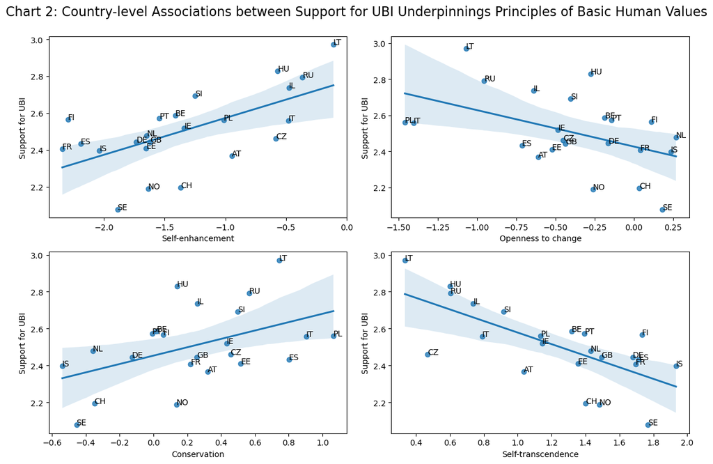

```python
import pandas as pd
import matplotlib.pyplot as plt
import seaborn as sns

variables = ['self-enhancement', 'openness to change', 'conservation', 'self-transcendence']
data = pd.DataFrame({'country': df_1['cntry'].unique()})
for var in variables:
    data[var] = df_1.groupby('cntry')[var].mean().values
data['support_for_ubi'] = df_1.groupby('cntry')['support_for_ubi'].mean().values

fig, axes = plt.subplots(2, 2, figsize=(12, 8))
for i, ax in enumerate(axes.flat):
    sns.regplot(x=variables[i], y='support_for_ubi', data=data, ax=ax)
    ax.set_xlabel(variables[i].capitalize())
    ax.set_ylabel('Support for UBI')
    for j, txt in enumerate(data['country']):
        ax.annotate(txt, (data[variables[i]][j], data['support_for_ubi'][j]))

fig.suptitle("Chart 2: Country-level Associations between Support for UBI Underpinnings Principles of Basic Human Values", size=16, y=1)
plt.tight_layout()
plt.show()
```

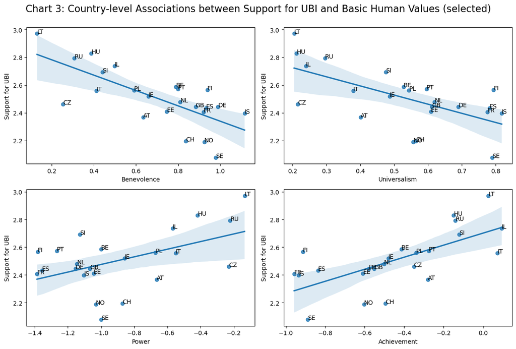

```python
variables = ['benevolence', 'universalism', 'power', 'achievement']
data = pd.DataFrame({'country': df_1['cntry'].unique()})
for var in variables:
    data[var] = df_1.groupby('cntry')[var].mean().values
data['support_for_ubi'] = df_1.groupby('cntry')['support_for_ubi'].mean().values

fig, axes = plt.subplots(2, 2, figsize=(12, 8))
for i, ax in enumerate(axes.flat):
    sns.regplot(x=variables[i], y='support_for_ubi', data=data, ax=ax)
    ax.set_xlabel(variables[i].capitalize())
    ax.set_ylabel('Support for UBI')
    for j, txt in enumerate(data['country']):
        ax.annotate(txt, (data[variables[i]][j], data['support_for_ubi'][j]))

fig.suptitle("Chart 3: Country-level Associations between Support for UBI and Basic Human Values (selected)", size=16, y=1)
plt.tight_layout()
plt.show()
```

#### Country-level Associations between Support for UBI and Social trust, Poltical Specturm and Media Bias

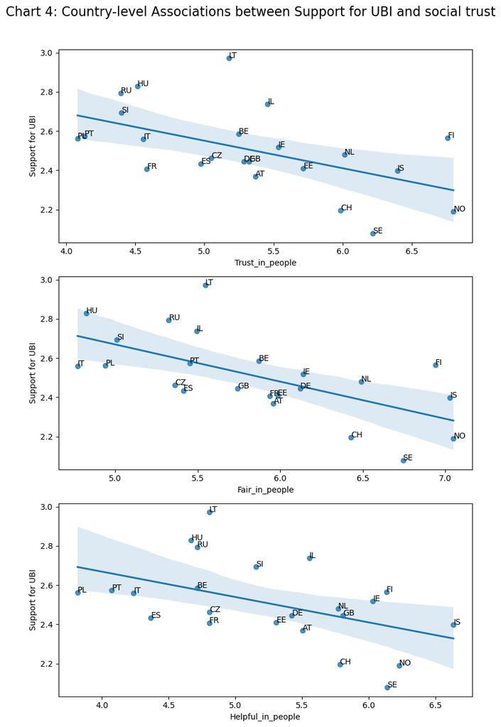

```python
variables = ['trust_in_people', 'fair_in_people','helpful_in_people']
data = pd.DataFrame({'country': df_1['cntry'].unique()})
for var in variables:
    data[var] = df_1.groupby('cntry')[var].mean().values
data['support_for_ubi'] = df_1.groupby('cntry')['support_for_ubi'].mean().values

fig, axes = plt.subplots(3, 1, figsize=(8, 12))
axes = axes.flatten()  # flatten the 2D array of axes to a 1D array
for i, ax in enumerate(axes):
    if i < len(variables):  # only plot the first 3 variables
        sns.regplot(x=variables[i], y='support_for_ubi', data=data, ax=ax)
        ax.set_xlabel(variables[i].capitalize())
        ax.set_ylabel('Support for UBI')
        for j, txt in enumerate(data['country']):
            ax.annotate(txt, (data[variables[i]][j], data['support_for_ubi'][j]))
plt.tight_layout()

fig.suptitle("Chart 4: Country-level Associations between Support for UBI and social trust", size=16, y=1.05)
plt.show()
```

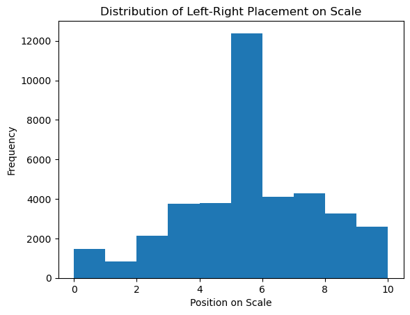

```python
import matplotlib.pyplot as plt

plt.hist(df_ess8['left_on_scale'])
plt.title('Distribution of Left-Right Placement on Scale')
plt.xlabel('Position on Scale')
plt.ylabel('Frequency')
plt.show()
```

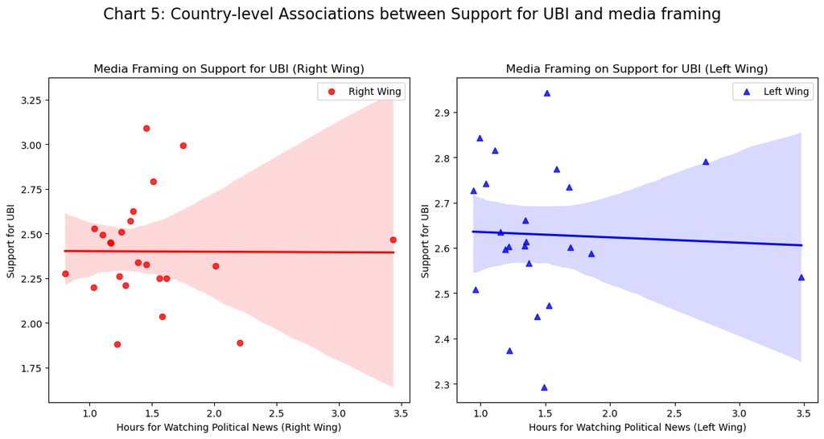

```python
# Split the data into left and right wing groups based on the mean value of 'left_on_scale'
df_right = df_1.loc[df_1['left_on_scale'] >= 7]
df_left = df_1.loc[df_1['left_on_scale'] <= 3]

# Aggregate the data by country and compute the mean of each variable
grouped_data_right = df_right.groupby('cntry')[['support_for_ubi', 'political_news_hour']].mean()
grouped_data_left = df_left.groupby('cntry')[['support_for_ubi', 'political_news_hour']].mean()

# Create a figure with two subplots side-by-side
fig, (ax1, ax2) = plt.subplots(1, 2, figsize=(12, 6))

# Create a scatter plot for the right wing group
sns.regplot(x=grouped_data_right['political_news_hour'], y=grouped_data_right['support_for_ubi'], color='red', label='Right Wing', marker='o', ax=ax1)
ax1.set_xlabel('Hours for Watching Political News (Right Wing)')
ax1.set_ylabel('Support for UBI')
ax1.set_title('Media Framing on Support for UBI (Right Wing)')
ax1.legend()

# Create a scatter plot for the left wing group
sns.regplot(x=grouped_data_left['political_news_hour'], y=grouped_data_left['support_for_ubi'], color='blue', label='Left Wing', marker='^', ax=ax2)
ax2.set_xlabel('Hours for Watching Political News (Left Wing)')
ax2.set_ylabel('Support for UBI')
ax2.set_title('Media Framing on Support for UBI (Left Wing)')
ax2.legend()

fig.suptitle("Chart 5: Country-level Associations between Support for UBI and media framing", size=16, y=1.05)
plt.tight_layout()
plt.show()
```

#### Economics Belief, Preferences, and Welfare Attitudes

```python
df_1['welfare_pos_impact'] = (df_1['preventing_poverty'] + df_1['promote_equality'] - df_1['less_caring'] - df_1['strain_on_the_economy'] - df_1['increasing_laziness'])/5
```

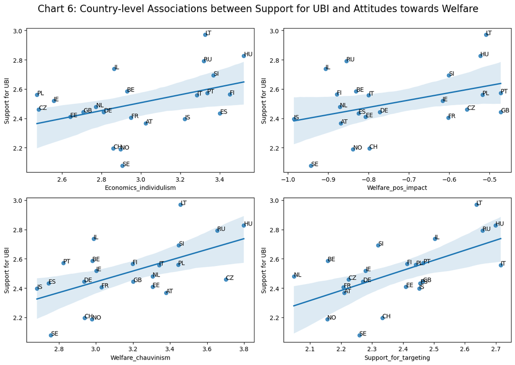

```python
variables = ['economics_individulism', 'welfare_pos_impact', 'welfare_chauvinism', 'support_for_targeting']

data = pd.DataFrame({'country': df_1['cntry'].unique()})
for var in variables:
    data[var] = df_1.groupby('cntry')[var].mean().values
data['support_for_ubi'] = df_1.groupby('cntry')['support_for_ubi'].mean().values

fig, axes = plt.subplots(2, 2, figsize=(12, 8))
for i, ax in enumerate(axes.flat):
    sns.regplot(x=variables[i], y='support_for_ubi', data=data, ax=ax)
    ax.set_xlabel(variables[i].capitalize())
    ax.set_ylabel('Support for UBI')
    for j, txt in enumerate(data['country']):
        ax.annotate(txt, (data[variables[i]][j], data['support_for_ubi'][j]))
plt.tight_layout()
fig.suptitle("Chart 6: Country-level Associations between Support for UBI and Attitudes towards Welfare", size=16, y=1.05)
plt.show()
```

```python
# Create a new DataFrame with the selected variables
df_corr = df_1[[
    'support_for_ubi',
    'security',
    'conformity',
    'tradition',
    'benevolence',
    'universalism',
    'selfdirection',
    'stimulation',
    'hedonism',
    'achievement',
    'power']]

# Calculate the Spearman rank correlation matrix
corr_matrix = df_corr.corr(method='spearman')

# Extract the correlation coefficients between Support for UBI and the other variables
ubi_corr = corr_matrix.loc['support_for_ubi',
   ['security',
    'conformity',
    'tradition',
    'benevolence',
    'universalism',
    'selfdirection',
    'stimulation',
    'hedonism',
    'achievement',
    'power']]

# Multiply the correlation coefficients by 4 to get a 1x4 matrix
ubi_corr = ubi_corr * 10

# Print the correlation matrix
print(ubi_corr)
```

```
security        -0.087224
conformity      -0.446142
tradition       -0.341587
benevolence     -0.960175
universalism    -0.365792
selfdirection   -0.644926
stimulation      0.586129
hedonism         0.123843
achievement      0.904861
power            0.684307
Name: support_for_ubi, dtype: float64
```

```python
df_1['support_for_ubi_dummy'] = np.where((df_1['support_for_ubi'] == 1) | (df_1['support_for_ubi'] == 2), 0,
                                         np.where((df_1['support_for_ubi'] == 3) | (df_1['support_for_ubi'] == 4), 1, np.nan))
```

```python
# Create a new DataFrame with the selected variables
df_corr_1 = df_1[[
    'support_for_ubi_dummy',
    'security',
    'conformity',
    'tradition',
    'benevolence',
    'universalism',
    'selfdirection',
    'stimulation',
    'hedonism',
    'achievement',
    'power']]

# Calculate the Spearman rank correlation matrix
corr_matrix_1 = df_corr_1.corr(method='spearman')

# Extract the correlation coefficients between Support for UBI and the other variables
ubi_corr_1 = corr_matrix_1.loc['support_for_ubi_dummy',
   ['security',
    'conformity',
    'tradition',
    'benevolence',
    'universalism',
    'selfdirection',
    'stimulation',
    'hedonism',
    'achievement',
    'power']]

# Multiply the correlation coefficients by 4 to get a 1x4 matrix
ubi_corr_1 = ubi_corr * 10

# Print the correlation matrix
print(ubi_corr_1)
```

```
security        -0.872239
conformity      -4.461416
tradition       -3.415873
benevolence     -9.601754
universalism    -3.657920
selfdirection   -6.449263
stimulation      5.861287
hedonism         1.238429
achievement      9.048606
power            6.843068
Name: support_for_ubi, dtype: float64
```

```python
data_corr_2 = {'support_for_ubi_ordinal': [-0.087224, -0.446142, -0.341587, -0.960175, -0.365792, -0.644926, 0.586129, 0.123843, 0.904861, 0.684307],
        'support_for_ubi_binary': [-0.872239, -4.461416, -3.415873, -9.601754, -3.657920, -6.449263, 5.861287, 1.238429, 9.048606, 6.843068]}

df_corr_2 = pd.DataFrame(data_corr_2 , index=['security', 'conformity', 'tradition', 'benevolence', 'universalism', 'selfdirection', 'stimulation', 'hedonism', 'achievement', 'power'])
```

```python
df_corr_2
```

|  | support_for_ubi_ordinal | support_for_ubi_binary |
| --- | --- | --- |
| security | -0.087224 | -0.872239 |
| conformity | -0.446142 | -4.461416 |
| tradition | -0.341587 | -3.415873 |
| benevolence | -0.960175 | -9.601754 |
| universalism | -0.365792 | -3.657920 |
| selfdirection | -0.644926 | -6.449263 |
| stimulation | 0.586129 | 5.861287 |
| hedonism | 0.123843 | 1.238429 |
| achievement | 0.904861 | 9.048606 |
| power | 0.684307 | 6.843068 |

```python
import dataframe_image as dfi
dfi.export(df_corr_2, 'table 2.png')
```

```
/Applications/Google Chrome.app/Contents/MacOS/Google Chrome
```

correlarion matrix of control var and support towards ubi

```python
human_value_descriptions = {
    'security': 'security values reflect the basic human need for safety, stability, and order.',
    'conformity': 'conformity values reflect the human need to respect and follow the norms, rules, and expectations of one’s social group.',
    'tradition': 'tradition values reflect the human need to maintain and preserve the customs, beliefs, and practices of one’s cultural heritage.',
    'benevolence': 'benevolence values reflect the human need to enhance the welfare and interests of others, particularly those who are vulnerable, weak, or disadvantaged.',
    'universalism': 'universalism values reflect the human need to understand, appreciate, and protect the welfare of all people and nature regardless of their social group, status, or identity.',
    'selfdirection': 'self-direction values reflect the human need to pursue one’s own interests, goals, and values, as well as to explore and learn about the world.',
    'stimulation': 'stimulation values reflect the human need to seek new experiences, sensations, and challenges that provide excitement, novelty, and variety.',
    'hedonism': 'hedonism values reflect the human need to seek pleasure, enjoyment, and sensuous gratification in life.',
    'achievement': 'achievement values reflect the human need to strive for excellence, mastery, and success in one’s endeavors.',
    'power': 'power values reflect the human need to seek social status, prestige, and control over people and resources.',
    'self-enhancement': 'self-enhancement values reflect the human need to enhance one’s self-esteem, self-confidence, and self-worth.',
    'openness to change': 'openness-to-change values reflect the human need to embrace change, innovation, and creativity, as well as to challenge the status quo.',
    'conservation': 'conservation values reflect the human need to preserve and protect the social and natural order, as well as to maintain the stability and continuity of one’s social group and culture.',
    'self-transcendence': 'self-transcendence values reflect the human need to connect with something beyond the self, such as nature, humanity, spirituality, or the universe.',
}

human_value_labels = {
    'security',
    'conformity',
    'tradition',
    'benevolence',
    'universalism',
    'selfdirection',
    'stimulation',
    'hedonism',
    'achievement',
    'power',
    'self enhancement',
    'openness to change',
    'conservation',
    'self transcendence',
}

# set the column names to the variable names
human_value_df.columns = list(human_value_labels)

# create a new DataFrame with the variable labels and descriptions
human_value_desc_df = pd.DataFrame({'Variable Name': human_value_df.columns,
                        'Description': list(human_value_descriptions.values())})



# add left padding to each cell in the DataFrame
human_value_desc_df.style.set_properties(**{'text-align': 'left', 'padding-left': '10px'})


# Set the maximum width of the Description column
pd.set_option('display.max_colwidth', 200)

# Set the display options to increase the maximum column width
pd.set_option("display.html.table_schema", False)

# display the description table
human_value_desc_df
```

|  | Variable Name | Description |
| --- | --- | --- |
| 0 | self transcendence | security values reflect the basic human need for safety, stability, and order. |
| 1 | achievement | conformity values reflect the human need to respect and follow the norms, rules, and expectations of one’s social group. |
| 2 | self enhancement | tradition values reflect the human need to maintain and preserve the customs, beliefs, and practices of one’s cultural heritage. |
| 3 | conservation | benevolence values reflect the human need to enhance the welfare and interests of others, particularly those who are vulnerable, weak, or disadvantaged. |
| 4 | stimulation | universalism values reflect the human need to understand, appreciate, and protect the welfare of all people and nature regardless of their social group, status, or identity. |
| 5 | benevolence | self-direction values reflect the human need to pursue one’s own interests, goals, and values, as well as to explore and learn about the world. |
| 6 | hedonism | stimulation values reflect the human need to seek new experiences, sensations, and challenges that provide excitement, novelty, and variety. |
| 7 | openness to change | hedonism values reflect the human need to seek pleasure, enjoyment, and sensuous gratification in life. |
| 8 | power | achievement values reflect the human need to strive for excellence, mastery, and success in one’s endeavors. |
| 9 | selfdirection | power values reflect the human need to seek social status, prestige, and control over people and resources. |
| 10 | security | self-enhancement values reflect the human need to enhance one’s self-esteem, self-confidence, and self-worth. |
| 11 | universalism | openness-to-change values reflect the human need to embrace change, innovation, and creativity, as well as to challenge the status quo. |
| 12 | tradition | conservation values reflect the human need to preserve and protect the social and natural order, as well as to maintain the stability and continuity of one’s social group and culture. |
| 13 | conformity | self-transcendence values reflect the human need to connect with something beyond the self, such as nature, humanity, spirituality, or the universe. |

```python
import dataframe_image as dfi
dfi.export(human_value_desc_df, 'tabel 3.png')
```

```
/Applications/Google Chrome.app/Contents/MacOS/Google Chrome
```

```python
df_1
```

|  | idno | cntry | security | conformity | tradition | benevolence | universalism | selfdirection | stimulation | hedonism | ... | age_group | is_bachelor | income_group | difficult_on_present_income | live_with_child | is_unemployed | was_unemployed_exceed_3months | likely_to_become_unemployed | welfare_pos_impact | support_for_ubi_dummy |
| --- | --- | --- | --- | --- | --- | --- | --- | --- | --- | --- | --- | --- | --- | --- | --- | --- | --- | --- | --- | --- | --- |
| 0 | 1 | AT | -1.095238 | -2.595238 | -1.095238 | 1.904762 | 1.904762 | 0.404762 | -0.095238 | -0.595238 | ... | 30 | 1.0 | NaN | 2.0 | 2.0 | 0.0 | 1.0 | NaN | -2.6 | 1.0 |
| 1 | 2 | AT | -0.928571 | -1.428571 | -0.928571 | 1.071429 | 1.238095 | 1.071429 | -0.428571 | -0.428571 | ... | 50 | 0.0 | 5.0 | 2.0 | 2.0 | 0.0 | 1.0 | 2.0 | -0.4 | 1.0 |
| 2 | 4 | AT | 2.095238 | -0.904762 | 0.595238 | 1.095238 | 1.095238 | 0.595238 | -2.904762 | 0.595238 | ... | 60 | 0.0 | 2.0 | 2.0 | 2.0 | 0.0 | 1.0 | 1.0 | -0.4 | 0.0 |
| 3 | 6 | AT | 0.428571 | -1.071429 | 0.428571 | -0.071429 | 0.095238 | 0.428571 | -0.571429 | 0.428571 | ... | 50 | 0.0 | 4.0 | 2.0 | 2.0 | 0.0 | 0.0 | 1.0 | -0.4 | NaN |
| 4 | 10 | AT | -0.928571 | -0.928571 | 0.071429 | 1.571429 | 0.904762 | 0.571429 | -1.428571 | 1.571429 | ... | 20 | 0.0 | 2.0 | 2.0 | 2.0 | 1.0 | 0.0 | 4.0 | -1.6 | 1.0 |
| ... | ... | ... | ... | ... | ... | ... | ... | ... | ... | ... | ... | ... | ... | ... | ... | ... | ... | ... | ... | ... | ... |
| 44382 | 1303 | SI | 0.714286 | -1.785714 | 0.214286 | 0.714286 | -1.285714 | 0.714286 | 0.714286 | 0.714286 | ... | 60 | 0.0 | 4.0 | 2.0 | 2.0 | 0.0 | 0.0 | NaN | 0.4 | 1.0 |
| 44383 | 1304 | SI | 0.404762 | 0.404762 | -0.095238 | 0.904762 | 0.238095 | 0.904762 | -1.595238 | -0.595238 | ... | 40 | 1.0 | NaN | 1.0 | 1.0 | 0.0 | 0.0 | 2.0 | -0.6 | NaN |
| 44384 | 1305 | SI | 0.595238 | 1.095238 | 0.595238 | 0.095238 | 0.761905 | 0.595238 | -0.904762 | -2.404762 | ... | 60 | 1.0 | 7.0 | 1.0 | 1.0 | 0.0 | 1.0 | 1.0 | -1.4 | 1.0 |
| 44385 | 1306 | SI | 0.500000 | -2.000000 | -1.000000 | 0.000000 | 0.000000 | 0.500000 | 0.500000 | 1.000000 | ... | 40 | 1.0 | 10.0 | 1.0 | 1.0 | 0.0 | 0.0 | 2.0 | -1.0 | 1.0 |
| 44386 | 1307 | SI | -0.666667 | -0.166667 | 0.333333 | 0.833333 | -1.000000 | 0.833333 | 0.833333 | 0.333333 | ... | 50 | 0.0 | NaN | 2.0 | 1.0 | 1.0 | 1.0 | 4.0 | -1.0 | 1.0 |

44387 rows × 46 columns

# Modelling

#### M1: Multilayer logistic modelling

Examing country-level fixed effect would help to exploring the variance caused by diffference between country. However, to perform the logistic regression, it's essential to handle missing values in your dataset. Removing all missing values from the DataFrame is one approach, but we should also consider the randomness of missing.

```python
import statsmodels.api as sm
import statsmodels.formula.api as smf

# Remove rows with missing outcome values
df_lm = df_1.dropna(subset=['support_for_ubi_dummy'])

df_lm.shape
```

```
(40592, 46)
```

```python
# Fit the linear mixed model
model = smf.mixedlm("support_for_ubi_dummy ~ 1", df_lm, groups=df_lm["cntry"], re_formula="~1")
result = model.fit()
```

```python
# Calculate the intraclass correlation
var_country = result.cov_re.iloc[0, 0]
var_error = result.scale
icc = var_country / (var_country + var_error)

print("Intraclass Correlation (ICC):", icc)
```

```
Intraclass Correlation (ICC): 0.05385067752832008
```

The Intraclass Correlation (ICC) is a measure of the proportion of total variance in the outcome variable that can be attributed to the grouping structure, in this case, the country-level. ICC values range from 0 to 1.

In your case, the ICC value is approximately 0.054 (rounded to 3 decimal places). This means that about 5.4% of the total variability in the outcome variable can be explained by differences between countries. The remaining 94.6% of the variability is due to differences within countries (i.e., individual-level variation) or other unmeasured factors.

Interpreting the ICC value depends on the context and research question. Here's a general guideline:

If the ICC is close to 0, it means that the country-level effect is relatively small compared to individual-level variation or other factors. In this case, including a random effect for countries may not be necessary or provide substantial improvements to the model. If the ICC is close to 1, it means that the country-level effect accounts for a large proportion of the total variance in the outcome variable. In this scenario, accounting for the country-level effect in the model is crucial to obtain accurate estimates and make appropriate inferences. In your case, the ICC value of 0.054 suggests that the country-level effect contributes a small portion of the total variance in the outcome variable. Depending on the context and research question, this might indicate that the focus should be on individual-level variables or other factors that explain more of the variation in the outcome. However, even small ICC values can be meaningful in certain situations, so it is essential to consider the context when interpreting the ICC value.

```python
df_lm.columns
```

```
Index(['idno', 'cntry', 'security', 'conformity', 'tradition', 'benevolence',
       'universalism', 'selfdirection', 'stimulation', 'hedonism',
       'achievement', 'power', 'self-enhancement', 'openness to change',
       'conservation', 'self-transcendence', 'political_news_hour',
       'trust_in_people', 'fair_in_people', 'helpful_in_people',
       'distance_to_party', 'left_on_scale', 'economics_individulism',
       'economics_fainess', 'strain_on_the_economy', 'preventing_poverty',
       'promote_equality', 'increasing_laziness', 'less_caring',
       'welfare_chauvinism', 'support_for_targeting', 'support_for_ubi',
       'happy_level', 'healthy_level', 'is_born_in_country', 'is_female',
       'age_group', 'is_bachelor', 'income_group',
       'difficult_on_present_income', 'live_with_child', 'is_unemployed',
       'was_unemployed_exceed_3months', 'likely_to_become_unemployed',
       'welfare_pos_impact', 'support_for_ubi_dummy'],
      dtype='object')
```

individual_characteristic = ['is_female', 'age_group', 'is_bachelor', 'income_group', 'difficult_on_present_income', 'live_with_child', 'is_unemployed', 'was_unemployed_exceed_3months', 'likely_to_become_unemployed','happy_level', 'healthy_level', 'is_born_in_country']

```python
individual_characteristic = ['is_female',
                             'age_group', 'is_bachelor', 'income_group',
                             'difficult_on_present_income', 'live_with_child', 'is_unemployed',
                             'was_unemployed_exceed_3months', 'likely_to_become_unemployed', 'happy_level', 'healthy_level', 'is_born_in_country']

# Calculate the number of non-missing values required to keep a column
threshold = len(df_lm) - 3000

# Drop columns with more than 3000 missing values
df_lm_clean = df_lm[individual_characteristic].dropna(axis=1, thresh=threshold)

# Print the remaining columns
print(df_lm_clean.columns)
```

```
Index(['is_female', 'age_group', 'is_bachelor', 'difficult_on_present_income',
       'live_with_child', 'is_unemployed', 'was_unemployed_exceed_3months',
       'healthy_level'],
      dtype='object')
```

```python
def update_age_group(age):
    if age == 990:
        return np.nan
    elif age in [70, 80, 90, 100]:
        return 70
    else:
        return age

df_lm['age_group'] = df_lm['age_group'].apply(update_age_group)
```

```python
age_group_frequency = df_lm['age_group'].value_counts()
print(age_group_frequency)
```

```
50.0    7064
60.0    6881
40.0    6758
30.0    6339
70.0    5959
20.0    5397
10.0    2085
Name: age_group, dtype: int64
```

```python
import pandas as pd
import statsmodels.api as sm
import statsmodels.formula.api as smf
from patsy import dmatrices

# Create the formula for the logistic regression
formula = "support_for_ubi_dummy ~ 1 + is_female + C(age_group) + is_bachelor +  \
           difficult_on_present_income + live_with_child + is_unemployed + \
           was_unemployed_exceed_3months + \
           healthy_level"


model = smf.logit(formula, data=df_lm, groups=df_lm['cntry']).fit()

# Print the model summary
print(model.summary())
```

```
Optimization terminated successfully.
         Current function value: 0.678345
         Iterations 4
                             Logit Regression Results
=================================================================================
Dep. Variable:     support_for_ubi_dummy   No. Observations:                39847
Model:                             Logit   Df Residuals:                    39833
Method:                              MLE   Df Model:                           13
Date:                   Wed, 10 May 2023   Pseudo R-squ.:                 0.01667
Time:                           12:46:31   Log-Likelihood:                -27030.
converged:                          True   LL-Null:                       -27488.
Covariance Type:               nonrobust   LLR p-value:                1.574e-187
=================================================================================================
                                    coef    std err          z      P>|z|      [0.025      0.975]
-------------------------------------------------------------------------------------------------
Intercept                        -0.0997      0.073     -1.360      0.174      -0.243       0.044
C(age_group)[T.20.0]             -0.2467      0.056     -4.430      0.000      -0.356      -0.138
C(age_group)[T.30.0]             -0.4105      0.057     -7.228      0.000      -0.522      -0.299
C(age_group)[T.40.0]             -0.5290      0.057     -9.297      0.000      -0.640      -0.417
C(age_group)[T.50.0]             -0.5825      0.055    -10.575      0.000      -0.690      -0.475
C(age_group)[T.60.0]             -0.6032      0.055    -11.050      0.000      -0.710      -0.496
C(age_group)[T.70.0]             -0.6248      0.056    -11.223      0.000      -0.734      -0.516
is_female                         0.0139      0.020      0.678      0.498      -0.026       0.054
is_bachelor                       0.0849      0.025      3.452      0.001       0.037       0.133
difficult_on_present_income       0.3157      0.014     22.993      0.000       0.289       0.343
live_with_child                   0.0127      0.025      0.519      0.603      -0.035       0.061
is_unemployed                     0.0387      0.056      0.696      0.487      -0.070       0.148
was_unemployed_exceed_3months     0.0954      0.024      3.942      0.000       0.048       0.143
healthy_level                     0.0300      0.013      2.372      0.018       0.005       0.055
=================================================================================================
```

```python
# List of basic human values
values = ['security', 'conformity', 'tradition', 'benevolence',
       'universalism', 'selfdirection', 'stimulation', 'hedonism',
       'achievement', 'power']

# Initialize an empty DataFrame to store the coefficients
coef_table = pd.DataFrame(columns=['value', 'coef'])

# Iterate through the basic human values and run separate logistic regression models
for value in values:
    # Create the formula for the logistic regression
    formula = f"support_for_ubi_dummy ~ {value}"

    # Fit the logistic regression model
    model = smf.logit(formula, data=df_lm).fit(disp=0)  # disp=0 to suppress output

    # Get the coefficient for the value
    coef = model.params[value]

    # Append the coefficient to the table
    coef_table = coef_table.append({'value': value, 'coef': coef}, ignore_index=True)

# Print the table with the coefficients
print("Coefficients for the 10 basic human values:")
print(coef_table)
```

```
Coefficients for the 10 basic human values:
           value      coef
0       security -0.005106
1     conformity -0.079654
2      tradition -0.057674
3    benevolence -0.255924
4   universalism -0.079147
5  selfdirection -0.138980
6    stimulation  0.092891
7       hedonism  0.012641
8    achievement  0.177130
9          power  0.125381
```

### Model_1 Basic Human Value

select values: benevolence, achievement, power, self-direction, stimulation, universalism

```python
# Create the formula for the logistic regression
formula = "support_for_ubi_dummy ~ 1 + is_female + C(age_group) + is_bachelor +  \
           difficult_on_present_income + live_with_child + is_unemployed + \
           was_unemployed_exceed_3months + \
           healthy_level + \
           benevolence + achievement + power + selfdirection + stimulation + universalism"


model_1 = smf.logit(formula, data=df_lm, groups=df_lm['cntry']).fit()

# Print the model summary
print(model_1.summary())
```

```
Optimization terminated successfully.
         Current function value: 0.672875
         Iterations 4
                             Logit Regression Results
=================================================================================
Dep. Variable:     support_for_ubi_dummy   No. Observations:                39847
Model:                             Logit   Df Residuals:                    39827
Method:                              MLE   Df Model:                           19
Date:                   Wed, 10 May 2023   Pseudo R-squ.:                 0.02460
Time:                           12:46:31   Log-Likelihood:                -26812.
converged:                          True   LL-Null:                       -27488.
Covariance Type:               nonrobust   LLR p-value:                2.163e-275
=================================================================================================
                                    coef    std err          z      P>|z|      [0.025      0.975]
-------------------------------------------------------------------------------------------------
Intercept                         0.0567      0.075      0.754      0.451      -0.091       0.204
C(age_group)[T.20.0]             -0.2105      0.056     -3.762      0.000      -0.320      -0.101
C(age_group)[T.30.0]             -0.3496      0.057     -6.105      0.000      -0.462      -0.237
C(age_group)[T.40.0]             -0.4466      0.058     -7.758      0.000      -0.559      -0.334
C(age_group)[T.50.0]             -0.4732      0.056     -8.452      0.000      -0.583      -0.363
C(age_group)[T.60.0]             -0.4677      0.056     -8.372      0.000      -0.577      -0.358
C(age_group)[T.70.0]             -0.4744      0.057     -8.279      0.000      -0.587      -0.362
is_female                         0.0600      0.021      2.875      0.004       0.019       0.101
is_bachelor                       0.0530      0.025      2.111      0.035       0.004       0.102
difficult_on_present_income       0.2874      0.014     20.572      0.000       0.260       0.315
live_with_child                   0.0032      0.025      0.131      0.896      -0.045       0.052
is_unemployed                     0.0514      0.056      0.920      0.358      -0.058       0.161
was_unemployed_exceed_3months     0.1153      0.024      4.713      0.000       0.067       0.163
healthy_level                     0.0359      0.013      2.816      0.005       0.011       0.061
benevolence                      -0.1423      0.018     -8.120      0.000      -0.177      -0.108
achievement                       0.1303      0.012     10.482      0.000       0.106       0.155
power                             0.0663      0.014      4.910      0.000       0.040       0.093
selfdirection                    -0.0828      0.014     -6.036      0.000      -0.110      -0.056
stimulation                       0.0865      0.011      7.715      0.000       0.065       0.109
universalism                      0.1703      0.020      8.705      0.000       0.132       0.209
=================================================================================================
```

#### Model 2: Social trust and media framing

```python
# Create the formula for the logistic regression
formula = "support_for_ubi_dummy ~ 1 + is_female + C(age_group) + is_bachelor +  \
           difficult_on_present_income + live_with_child + is_unemployed + \
           was_unemployed_exceed_3months + \
           healthy_level + \
           benevolence + achievement + power + selfdirection + stimulation + universalism + \
           fair_in_people + trust_in_people + helpful_in_people + \
           political_news_hour + left_on_scale + \
           political_news_hour:left_on_scale"


model_2 = smf.logit(formula, data=df_lm, groups=df_lm['cntry']).fit()

# Print the model summary
print(model_2.summary())
```

```
Optimization terminated successfully.
         Current function value: 0.673453
         Iterations 4
                             Logit Regression Results
=================================================================================
Dep. Variable:     support_for_ubi_dummy   No. Observations:                35011
Model:                             Logit   Df Residuals:                    34985
Method:                              MLE   Df Model:                           25
Date:                   Wed, 10 May 2023   Pseudo R-squ.:                 0.02616
Time:                           12:46:32   Log-Likelihood:                -23578.
converged:                          True   LL-Null:                       -24212.
Covariance Type:               nonrobust   LLR p-value:                1.100e-251
=====================================================================================================
                                        coef    std err          z      P>|z|      [0.025      0.975]
-----------------------------------------------------------------------------------------------------
Intercept                             0.2407      0.098      2.461      0.014       0.049       0.432
C(age_group)[T.20.0]                 -0.1821      0.061     -2.974      0.003      -0.302      -0.062
C(age_group)[T.30.0]                 -0.2821      0.063     -4.506      0.000      -0.405      -0.159
C(age_group)[T.40.0]                 -0.3793      0.063     -6.028      0.000      -0.503      -0.256
C(age_group)[T.50.0]                 -0.4129      0.061     -6.750      0.000      -0.533      -0.293
C(age_group)[T.60.0]                 -0.3956      0.061     -6.477      0.000      -0.515      -0.276
C(age_group)[T.70.0]                 -0.4032      0.063     -6.425      0.000      -0.526      -0.280
is_female                             0.0279      0.022      1.251      0.211      -0.016       0.072
is_bachelor                           0.0484      0.027      1.827      0.068      -0.004       0.100
difficult_on_present_income           0.2868      0.015     18.786      0.000       0.257       0.317
live_with_child                       0.0037      0.026      0.140      0.889      -0.048       0.056
is_unemployed                         0.0647      0.060      1.070      0.285      -0.054       0.183
was_unemployed_exceed_3months         0.1099      0.026      4.208      0.000       0.059       0.161
healthy_level                         0.0306      0.014      2.230      0.026       0.004       0.058
benevolence                          -0.1286      0.019     -6.813      0.000      -0.166      -0.092
achievement                           0.1273      0.013      9.566      0.000       0.101       0.153
power                                 0.0553      0.014      3.828      0.000       0.027       0.084
selfdirection                        -0.0791      0.015     -5.371      0.000      -0.108      -0.050
stimulation                           0.0801      0.012      6.702      0.000       0.057       0.103
universalism                          0.1433      0.021      6.762      0.000       0.102       0.185
fair_in_people                       -0.0160      0.007     -2.463      0.014      -0.029      -0.003
trust_in_people                       0.0050      0.006      0.836      0.403      -0.007       0.017
helpful_in_people                     0.0201      0.006      3.378      0.001       0.008       0.032
political_news_hour                   0.0280      0.013      2.161      0.031       0.003       0.053
left_on_scale                        -0.0571      0.006     -9.376      0.000      -0.069      -0.045
political_news_hour:left_on_scale    -0.0052      0.002     -2.272      0.023      -0.010      -0.001
=====================================================================================================
```

```python
### Model 3: Belief and Preferences

# Create the formula for the logistic regression
formula = "support_for_ubi_dummy ~ 1 + is_female + C(age_group) + is_bachelor +  \
           difficult_on_present_income + live_with_child + is_unemployed + \
           was_unemployed_exceed_3months + \
           healthy_level + \
           benevolence + achievement + power + selfdirection + stimulation + universalism + \
           fair_in_people + trust_in_people + helpful_in_people + \
           political_news_hour + left_on_scale + \
           political_news_hour:left_on_scale + \
           economics_individulism + economics_fainess"


model_3 = smf.logit(formula, data=df_lm, groups=df_lm['cntry']).fit()

# Print the model summary
print(model_3.summary())
```

```
Optimization terminated successfully.
         Current function value: 0.664995
         Iterations 5
                             Logit Regression Results
=================================================================================
Dep. Variable:     support_for_ubi_dummy   No. Observations:                34493
Model:                             Logit   Df Residuals:                    34465
Method:                              MLE   Df Model:                           27
Date:                   Wed, 10 May 2023   Pseudo R-squ.:                 0.03848
Time:                           12:46:32   Log-Likelihood:                -22938.
converged:                          True   LL-Null:                       -23856.
Covariance Type:               nonrobust   LLR p-value:                     0.000
=====================================================================================================
                                        coef    std err          z      P>|z|      [0.025      0.975]
-----------------------------------------------------------------------------------------------------
Intercept                             0.6942      0.110      6.311      0.000       0.479       0.910
C(age_group)[T.20.0]                 -0.1688      0.062     -2.715      0.007      -0.291      -0.047
C(age_group)[T.30.0]                 -0.2757      0.064     -4.336      0.000      -0.400      -0.151
C(age_group)[T.40.0]                 -0.3772      0.064     -5.900      0.000      -0.502      -0.252
C(age_group)[T.50.0]                 -0.4316      0.062     -6.944      0.000      -0.553      -0.310
C(age_group)[T.60.0]                 -0.4114      0.062     -6.630      0.000      -0.533      -0.290
C(age_group)[T.70.0]                 -0.4554      0.064     -7.139      0.000      -0.580      -0.330
is_female                             0.0258      0.023      1.140      0.254      -0.019       0.070
is_bachelor                           0.0587      0.027      2.176      0.030       0.006       0.111
difficult_on_present_income           0.2486      0.016     15.946      0.000       0.218       0.279
live_with_child                       0.0101      0.027      0.377      0.706      -0.043       0.063
is_unemployed                         0.0645      0.061      1.049      0.294      -0.056       0.185
was_unemployed_exceed_3months         0.0899      0.027      3.388      0.001       0.038       0.142
healthy_level                         0.0319      0.014      2.279      0.023       0.004       0.059
benevolence                          -0.1286      0.019     -6.689      0.000      -0.166      -0.091
achievement                           0.1292      0.014      9.537      0.000       0.103       0.156
power                                 0.0689      0.015      4.677      0.000       0.040       0.098
selfdirection                        -0.0624      0.015     -4.156      0.000      -0.092      -0.033
stimulation                           0.0843      0.012      6.926      0.000       0.060       0.108
universalism                          0.0976      0.022      4.498      0.000       0.055       0.140
fair_in_people                       -0.0150      0.007     -2.258      0.024      -0.028      -0.002
trust_in_people                       0.0037      0.006      0.611      0.541      -0.008       0.016
helpful_in_people                     0.0195      0.006      3.214      0.001       0.008       0.031
political_news_hour                   0.0261      0.013      1.991      0.047       0.000       0.052
left_on_scale                        -0.0419      0.006     -6.706      0.000      -0.054      -0.030
political_news_hour:left_on_scale    -0.0050      0.002     -2.179      0.029      -0.010      -0.001
economics_individulism                0.0678      0.010      6.518      0.000       0.047       0.088
economics_fainess                    -0.2582      0.012    -20.805      0.000      -0.283      -0.234
=====================================================================================================
```

### Model 4: welfare attitudes

```python
### Model 3: Belief and Preferences

# Create the formula for the logistic regression
formula = "support_for_ubi_dummy ~ 1 + is_female + C(age_group) + is_bachelor +  \
           difficult_on_present_income + live_with_child + is_unemployed + \
           was_unemployed_exceed_3months + \
           healthy_level + \
           benevolence + achievement + power + selfdirection + stimulation + universalism + \
           fair_in_people + trust_in_people + helpful_in_people + \
           political_news_hour + left_on_scale + \
           political_news_hour:left_on_scale + \
           economics_individulism + economics_fainess + \
           strain_on_the_economy + preventing_poverty + promote_equality + increasing_laziness + less_caring + welfare_chauvinism + support_for_targeting"

### country-level fixed effect logistic regression
model_4 = smf.logit(formula, data=df_lm, groups=df_lm['cntry']).fit()

# Print the model summary
print(model_4.summary())
```

```
Optimization terminated successfully.
         Current function value: 0.658722
         Iterations 5
                             Logit Regression Results
=================================================================================
Dep. Variable:     support_for_ubi_dummy   No. Observations:                31389
Model:                             Logit   Df Residuals:                    31354
Method:                              MLE   Df Model:                           34
Date:                   Wed, 10 May 2023   Pseudo R-squ.:                 0.04808
Time:                           12:46:32   Log-Likelihood:                -20677.
converged:                          True   LL-Null:                       -21721.
Covariance Type:               nonrobust   LLR p-value:                     0.000
=====================================================================================================
                                        coef    std err          z      P>|z|      [0.025      0.975]
-----------------------------------------------------------------------------------------------------
Intercept                             0.0641      0.136      0.470      0.639      -0.203       0.331
C(age_group)[T.20.0]                 -0.1290      0.065     -1.981      0.048      -0.257      -0.001
C(age_group)[T.30.0]                 -0.2087      0.067     -3.127      0.002      -0.340      -0.078
C(age_group)[T.40.0]                 -0.2976      0.067     -4.434      0.000      -0.429      -0.166
C(age_group)[T.50.0]                 -0.3679      0.065     -5.642      0.000      -0.496      -0.240
C(age_group)[T.60.0]                 -0.3781      0.065     -5.799      0.000      -0.506      -0.250
C(age_group)[T.70.0]                 -0.4327      0.067     -6.432      0.000      -0.565      -0.301
is_female                             0.0423      0.024      1.769      0.077      -0.005       0.089
is_bachelor                           0.0247      0.029      0.867      0.386      -0.031       0.081
difficult_on_present_income           0.2249      0.017     13.484      0.000       0.192       0.258
live_with_child                       0.0160      0.028      0.562      0.574      -0.040       0.072
is_unemployed                         0.0532      0.065      0.816      0.415      -0.075       0.181
was_unemployed_exceed_3months         0.0925      0.028      3.308      0.001       0.038       0.147
healthy_level                         0.0218      0.015      1.466      0.143      -0.007       0.051
benevolence                          -0.1217      0.021     -5.928      0.000      -0.162      -0.081
achievement                           0.1258      0.014      8.767      0.000       0.098       0.154
power                                 0.0509      0.016      3.235      0.001       0.020       0.082
selfdirection                        -0.0547      0.016     -3.439      0.001      -0.086      -0.024
stimulation                           0.0844      0.013      6.535      0.000       0.059       0.110
universalism                          0.0732      0.023      3.153      0.002       0.028       0.119
fair_in_people                       -0.0163      0.007     -2.310      0.021      -0.030      -0.002
trust_in_people                      -0.0035      0.006     -0.539      0.590      -0.016       0.009
helpful_in_people                     0.0124      0.006      1.926      0.054      -0.000       0.025
political_news_hour                   0.0296      0.014      2.087      0.037       0.002       0.057
left_on_scale                        -0.0352      0.007     -5.234      0.000      -0.048      -0.022
political_news_hour:left_on_scale    -0.0059      0.002     -2.362      0.018      -0.011      -0.001
economics_individulism                0.0479      0.011      4.315      0.000       0.026       0.070
economics_fainess                    -0.2329      0.013    -17.687      0.000      -0.259      -0.207
strain_on_the_economy                 0.0289      0.012      2.331      0.020       0.005       0.053
preventing_poverty                   -0.0086      0.014     -0.616      0.538      -0.036       0.019
promote_equality                     -0.0654      0.014     -4.708      0.000      -0.093      -0.038
increasing_laziness                   0.0828      0.014      5.972      0.000       0.056       0.110
less_caring                           0.0403      0.014      2.891      0.004       0.013       0.068
welfare_chauvinism                   -0.0463      0.012     -3.862      0.000      -0.070      -0.023
support_for_targeting                 0.2398      0.015     16.118      0.000       0.211       0.269
=====================================================================================================
```

```python
!pip install stargazer
```

```python
from stargazer.stargazer import Stargazer
import statsmodels.api as sm


# create a list of models to include in the table
models = [model, model_1, model_2, model_3, model_4]

# create a dataframe with the coefficients and standard errors for each model
data = {"Coefficients": [m.params.tolist() for m in models],
        "Standard Errors": [m.bse.tolist() for m in models]}
df = pd.DataFrame(data, index=["Model", "Model 1", "Model 2", "Model 3", "Model 4"])




# create the table
stargazer = Stargazer(models)
stargazer
```

|  | *Dependent variable:support_for_ubi_dummy* |  |  |  |  |
| --- | --- | --- | --- | --- | --- |
|  | (1) | (2) | (3) | (4) | (5) |
| C(age_group)[T.20.0] |  | -0.211*** | -0.182*** | -0.169*** | -0.129** |
|  |  | (0.056) | (0.061) | (0.062) | (0.065) |
| C(age_group)[T.30.0] |  | -0.350*** | -0.282*** | -0.276*** | -0.209*** |
|  |  | (0.057) | (0.063) | (0.064) | (0.067) |
| C(age_group)[T.40.0] |  | -0.447*** | -0.379*** | -0.377*** | -0.298*** |
|  |  | (0.058) | (0.063) | (0.064) | (0.067) |
| C(age_group)[T.50.0] |  | -0.473*** | -0.413*** | -0.432*** | -0.368*** |
|  |  | (0.056) | (0.061) | (0.062) | (0.065) |
| C(age_group)[T.60.0] |  | -0.468*** | -0.396*** | -0.411*** | -0.378*** |
|  |  | (0.056) | (0.061) | (0.062) | (0.065) |
| C(age_group)[T.70.0] |  | -0.474*** | -0.403*** | -0.455*** | -0.433*** |
|  |  | (0.057) | (0.063) | (0.064) | (0.067) |
| Intercept | 0.279*** | 0.057 | 0.241** | 0.694*** | 0.064 |
|  | (0.014) | (0.075) | (0.098) | (0.110) | (0.136) |
| achievement |  | 0.130*** | 0.127*** | 0.129*** | 0.126*** |
|  |  | (0.012) | (0.013) | (0.014) | (0.014) |
| benevolence |  | -0.142*** | -0.129*** | -0.129*** | -0.122*** |
|  |  | (0.018) | (0.019) | (0.019) | (0.021) |
| difficult_on_present_income |  | 0.287*** | 0.287*** | 0.249*** | 0.225*** |
|  |  | (0.014) | (0.015) | (0.016) | (0.017) |
| economics_fainess |  |  |  | -0.258*** | -0.233*** |
|  |  |  |  | (0.012) | (0.013) |
| economics_individulism |  |  |  | 0.068*** | 0.048*** |
|  |  |  |  | (0.010) | (0.011) |
| fair_in_people |  |  | -0.016** | -0.015** | -0.016** |
|  |  |  | (0.007) | (0.007) | (0.007) |
| healthy_level |  | 0.036*** | 0.031** | 0.032** | 0.022 |
|  |  | (0.013) | (0.014) | (0.014) | (0.015) |
| helpful_in_people |  |  | 0.020*** | 0.019*** | 0.012* |
|  |  |  | (0.006) | (0.006) | (0.006) |
| increasing_laziness |  |  |  |  | 0.083*** |
|  |  |  |  |  | (0.014) |
| is_bachelor |  | 0.053** | 0.048* | 0.059** | 0.025 |
|  |  | (0.025) | (0.027) | (0.027) | (0.029) |
| is_female |  | 0.060*** | 0.028 | 0.026 | 0.042* |
|  |  | (0.021) | (0.022) | (0.023) | (0.024) |
| is_unemployed |  | 0.051 | 0.065 | 0.064 | 0.053 |
|  |  | (0.056) | (0.060) | (0.061) | (0.065) |
| left_on_scale |  |  | -0.057*** | -0.042*** | -0.035*** |
|  |  |  | (0.006) | (0.006) | (0.007) |
| less_caring |  |  |  |  | 0.040*** |
|  |  |  |  |  | (0.014) |
| live_with_child |  | 0.003 | 0.004 | 0.010 | 0.016 |
|  |  | (0.025) | (0.026) | (0.027) | (0.028) |
| political_news_hour |  |  | 0.028** | 0.026** | 0.030** |
|  |  |  | (0.013) | (0.013) | (0.014) |
| political_news_hour:left_on_scale |  |  | -0.005** | -0.005** | -0.006** |
|  |  |  | (0.002) | (0.002) | (0.002) |
| power | 0.125*** | 0.066*** | 0.055*** | 0.069*** | 0.051*** |
|  | (0.011) | (0.014) | (0.014) | (0.015) | (0.016) |
| preventing_poverty |  |  |  |  | -0.009 |
|  |  |  |  |  | (0.014) |
| promote_equality |  |  |  |  | -0.065*** |
|  |  |  |  |  | (0.014) |
| selfdirection |  | -0.083*** | -0.079*** | -0.062*** | -0.055*** |
|  |  | (0.014) | (0.015) | (0.015) | (0.016) |
| stimulation |  | 0.087*** | 0.080*** | 0.084*** | 0.084*** |
|  |  | (0.011) | (0.012) | (0.012) | (0.013) |
| strain_on_the_economy |  |  |  |  | 0.029** |
|  |  |  |  |  | (0.012) |
| support_for_targeting |  |  |  |  | 0.240*** |
|  |  |  |  |  | (0.015) |
| trust_in_people |  |  | 0.005 | 0.004 | -0.003 |
|  |  |  | (0.006) | (0.006) | (0.006) |
| universalism |  | 0.170*** | 0.143*** | 0.098*** | 0.073*** |
|  |  | (0.020) | (0.021) | (0.022) | (0.023) |
| was_unemployed_exceed_3months |  | 0.115*** | 0.110*** | 0.090*** | 0.093*** |
|  |  | (0.024) | (0.026) | (0.027) | (0.028) |
| welfare_chauvinism |  |  |  |  | -0.046*** |
|  |  |  |  |  | (0.012) |
| Observations | 40,592 | 39,847 | 35,011 | 34,493 | 31,389 |
| R<sup>2</sup> |  |  |  |  |  |
| Adjusted R<sup>2</sup> |  |  |  |  |  |
| Residual Std. Error | 1.000 (df=40590) | 1.000 (df=39827) | 1.000 (df=34985) | 1.000 (df=34465) | 1.000 (df=31354) |
| F Statistic | (df=1; 40590) | (df=19; 39827) | (df=25; 34985) | (df=27; 34465) | (df=34; 31354) |
| Note: | *p<0.1; **p<0.05; ***p<0.01 |  |  |  |  |

```python
import subprocess
```

```python
# generate LaTeX table and save to file
with open("table.tex", "w") as f:
    f.write(stargazer.render_html())

#subprocess.call(["pdflatex", "table.tex"])  # replace with your document name
```

```python
 print(stargazer.render_latex())
```

```
\begin{table}[!htbp] \centering
\begin{tabular}{@{\extracolsep{5pt}}lccccc}
\\[-1.8ex]\hline
\hline \\[-1.8ex]
& \multicolumn{5}{c}{\textit{Dependent variable:}} \
\cr \cline{5-6}
\\[-1.8ex] & (1) & (2) & (3) & (4) & (5) \\
\hline \\[-1.8ex]
 C(age_group)[T.20.0] & & -0.211$^{***}$ & -0.182$^{***}$ & -0.169$^{***}$ & -0.129$^{**}$ \\
  & & (0.056) & (0.061) & (0.062) & (0.065) \\
 C(age_group)[T.30.0] & & -0.350$^{***}$ & -0.282$^{***}$ & -0.276$^{***}$ & -0.209$^{***}$ \\
  & & (0.057) & (0.063) & (0.064) & (0.067) \\
 C(age_group)[T.40.0] & & -0.447$^{***}$ & -0.379$^{***}$ & -0.377$^{***}$ & -0.298$^{***}$ \\
  & & (0.058) & (0.063) & (0.064) & (0.067) \\
 C(age_group)[T.50.0] & & -0.473$^{***}$ & -0.413$^{***}$ & -0.432$^{***}$ & -0.368$^{***}$ \\
  & & (0.056) & (0.061) & (0.062) & (0.065) \\
 C(age_group)[T.60.0] & & -0.468$^{***}$ & -0.396$^{***}$ & -0.411$^{***}$ & -0.378$^{***}$ \\
  & & (0.056) & (0.061) & (0.062) & (0.065) \\
 C(age_group)[T.70.0] & & -0.474$^{***}$ & -0.403$^{***}$ & -0.455$^{***}$ & -0.433$^{***}$ \\
  & & (0.057) & (0.063) & (0.064) & (0.067) \\
 Intercept & 0.279$^{***}$ & 0.057$^{}$ & 0.241$^{**}$ & 0.694$^{***}$ & 0.064$^{}$ \\
  & (0.014) & (0.075) & (0.098) & (0.110) & (0.136) \\
 achievement & & 0.130$^{***}$ & 0.127$^{***}$ & 0.129$^{***}$ & 0.126$^{***}$ \\
  & & (0.012) & (0.013) & (0.014) & (0.014) \\
 benevolence & & -0.142$^{***}$ & -0.129$^{***}$ & -0.129$^{***}$ & -0.122$^{***}$ \\
  & & (0.018) & (0.019) & (0.019) & (0.021) \\
 difficult_on_present_income & & 0.287$^{***}$ & 0.287$^{***}$ & 0.249$^{***}$ & 0.225$^{***}$ \\
  & & (0.014) & (0.015) & (0.016) & (0.017) \\
 economics_fainess & & & & -0.258$^{***}$ & -0.233$^{***}$ \\
  & & & & (0.012) & (0.013) \\
 economics_individulism & & & & 0.068$^{***}$ & 0.048$^{***}$ \\
  & & & & (0.010) & (0.011) \\
 fair_in_people & & & -0.016$^{**}$ & -0.015$^{**}$ & -0.016$^{**}$ \\
  & & & (0.007) & (0.007) & (0.007) \\
 healthy_level & & 0.036$^{***}$ & 0.031$^{**}$ & 0.032$^{**}$ & 0.022$^{}$ \\
  & & (0.013) & (0.014) & (0.014) & (0.015) \\
 helpful_in_people & & & 0.020$^{***}$ & 0.019$^{***}$ & 0.012$^{*}$ \\
  & & & (0.006) & (0.006) & (0.006) \\
 increasing_laziness & & & & & 0.083$^{***}$ \\
  & & & & & (0.014) \\
```

[output cut: 34 more lines]

```
 was_unemployed_exceed_3months & & 0.115$^{***}$ & 0.110$^{***}$ & 0.090$^{***}$ & 0.093$^{***}$ \\
  & & (0.024) & (0.026) & (0.027) & (0.028) \\
 welfare_chauvinism & & & & & -0.046$^{***}$ \\
  & & & & & (0.012) \\
\hline \\[-1.8ex]
 Observations & 40,592 & 39,847 & 35,011 & 34,493 & 31,389 \\
 $R^2$ &  &  &  &  &  \\
 Adjusted $R^2$ &  &  &  &  &  \\
 Residual Std. Error & 1.000(df = 40590) & 1.000(df = 39827) & 1.000(df = 34985) & 1.000(df = 34465) & 1.000(df = 31354)  \\
 F Statistic & $^{}$ (df = 1.0; 40590.0) & $^{}$ (df = 19.0; 39827.0) & $^{}$ (df = 25.0; 34985.0) & $^{}$ (df = 27.0; 34465.0) & $^{}$ (df = 34.0; 31354.0) \\
\hline
\hline \\[-1.8ex]
\textit{Note:} & \multicolumn{5}{r}{$^{*}$p$<$0.1; $^{**}$p$<$0.05; $^{***}$p$<$0.01} \\
\end{tabular}
\end{table}
```

```python
import numpy as np
import pandas as pd
import matplotlib.pyplot as plt
%matplotlib inline
from sklearn.preprocessing import LabelEncoder, OneHotEncoder
from sklearn.model_selection import cross_val_score, validation_curve, learning_curve, train_test_split
from sklearn.metrics import roc_curve, auc
from sklearn.naive_bayes import GaussianNB
from sklearn.svm import SVC
```

```python
df_1.isnull().sum()
```

```
idno                                 0
cntry                                0
security                             0
conformity                           0
tradition                            0
benevolence                          0
universalism                         0
selfdirection                        0
stimulation                          0
hedonism                             0
achievement                          0
power                                0
self-enhancement                     0
openness to change                   0
conservation                         0
self-transcendence                   0
political_news_hour                524
trust_in_people                    115
fair_in_people                     315
helpful_in_people                  176
distance_to_party                25320
left_on_scale                     5804
economics_individulism             867
economics_fainess                  796
strain_on_the_economy             2163
preventing_poverty                1340
promote_equality                  1493
increasing_laziness               1031
less_caring                       1546
welfare_chauvinism                1984
support_for_targeting             2562
support_for_ubi                   3795
happy_level                      37884
healthy_level                       59
is_born_in_country                4716
is_female                            9
age_group                            0
is_bachelor                        217
income_group                      7942
difficult_on_present_income        524
live_with_child                     11
is_unemployed                        0
was_unemployed_exceed_3months      218
likely_to_become_unemployed      10287
welfare_pos_impact                3927
support_for_ubi_dummy             3795
dtype: int64
```

```python
df_svm = df_1.dropna(subset=['support_for_ubi_dummy'])

# Find columns with more than 3000 missing values
columns_to_drop = df_svm.columns[df_svm.isnull().sum() > 3000]

# Drop the identified columns
df_svm_1 = df_svm.drop(columns_to_drop, axis=1)
```

```python
df_svm_1.isnull().sum()

# drop missing values
df_svm_2= df_svm_1.dropna()
df_svm_2
```

|  | idno | cntry | security | conformity | tradition | benevolence | universalism | selfdirection | stimulation | hedonism | ... | healthy_level | is_female | age_group | is_bachelor | difficult_on_present_income | live_with_child | is_unemployed | was_unemployed_exceed_3months | welfare_pos_impact | support_for_ubi_dummy |
| --- | --- | --- | --- | --- | --- | --- | --- | --- | --- | --- | --- | --- | --- | --- | --- | --- | --- | --- | --- | --- | --- |
| 0 | 1 | AT | -1.095238 | -2.595238 | -1.095238 | 1.904762 | 1.904762 | 0.404762 | -0.095238 | -0.595238 | ... | 3.0 | 1.0 | 30 | 1.0 | 2.0 | 2.0 | 0.0 | 1.0 | -2.6 | 1.0 |
| 1 | 2 | AT | -0.928571 | -1.428571 | -0.928571 | 1.071429 | 1.238095 | 1.071429 | -0.428571 | -0.428571 | ... | 3.0 | 0.0 | 50 | 0.0 | 2.0 | 2.0 | 0.0 | 1.0 | -0.4 | 1.0 |
| 2 | 4 | AT | 2.095238 | -0.904762 | 0.595238 | 1.095238 | 1.095238 | 0.595238 | -2.904762 | 0.595238 | ... | 3.0 | 1.0 | 60 | 0.0 | 2.0 | 2.0 | 0.0 | 1.0 | -0.4 | 0.0 |
| 4 | 10 | AT | -0.928571 | -0.928571 | 0.071429 | 1.571429 | 0.904762 | 0.571429 | -1.428571 | 1.571429 | ... | 1.0 | 1.0 | 20 | 0.0 | 2.0 | 2.0 | 1.0 | 0.0 | -1.6 | 1.0 |
| 5 | 11 | AT | 1.523810 | 1.023810 | 1.023810 | 1.023810 | 0.857143 | -0.976190 | -2.476190 | -0.476190 | ... | 2.0 | 1.0 | 60 | 0.0 | 1.0 | 2.0 | 0.0 | 0.0 | -0.4 | 1.0 |
| ... | ... | ... | ... | ... | ... | ... | ... | ... | ... | ... | ... | ... | ... | ... | ... | ... | ... | ... | ... | ... | ... |
| 44381 | 1302 | SI | 0.333333 | -1.666667 | -0.166667 | 0.333333 | 0.000000 | 0.333333 | 0.333333 | 0.333333 | ... | 2.0 | 0.0 | 40 | 0.0 | 1.0 | 1.0 | 0.0 | 0.0 | 0.2 | 1.0 |
| 44382 | 1303 | SI | 0.714286 | -1.785714 | 0.214286 | 0.714286 | -1.285714 | 0.714286 | 0.714286 | 0.714286 | ... | 3.0 | 1.0 | 60 | 0.0 | 2.0 | 2.0 | 0.0 | 0.0 | 0.4 | 1.0 |
| 44384 | 1305 | SI | 0.595238 | 1.095238 | 0.595238 | 0.095238 | 0.761905 | 0.595238 | -0.904762 | -2.404762 | ... | 4.0 | 0.0 | 60 | 1.0 | 1.0 | 1.0 | 0.0 | 1.0 | -1.4 | 1.0 |
| 44385 | 1306 | SI | 0.500000 | -2.000000 | -1.000000 | 0.000000 | 0.000000 | 0.500000 | 0.500000 | 1.000000 | ... | 1.0 | 1.0 | 40 | 1.0 | 1.0 | 1.0 | 0.0 | 0.0 | -1.0 | 1.0 |
| 44386 | 1307 | SI | -0.666667 | -0.166667 | 0.333333 | 0.833333 | -1.000000 | 0.833333 | 0.833333 | 0.333333 | ... | 4.0 | 1.0 | 50 | 0.0 | 2.0 | 1.0 | 1.0 | 1.0 | -1.0 | 1.0 |

34424 rows × 40 columns

```python
# target array and feature matrix
y = df_svm_2['support_for_ubi_dummy']
X = df_svm_2.drop('support_for_ubi_dummy', axis=1)
y
```

```
0        1.0
1        1.0
2        0.0
4        1.0
5        1.0
        ...
44381    1.0
44382    1.0
44384    1.0
44385    1.0
44386    1.0
Name: support_for_ubi_dummy, Length: 34424, dtype: float64
```

```python
# encode the target array
lb = LabelEncoder()
lb.fit(y)
print(lb.classes_)
y = lb.transform(y)
y
```

```
[0. 1.]
```

```
array([1, 1, 0, ..., 1, 1, 1])
```

```python
X.columns
```

```
Index(['idno', 'cntry', 'security', 'conformity', 'tradition', 'benevolence',
       'universalism', 'selfdirection', 'stimulation', 'hedonism',
       'achievement', 'power', 'self-enhancement', 'openness to change',
       'conservation', 'self-transcendence', 'political_news_hour',
       'trust_in_people', 'fair_in_people', 'helpful_in_people',
       'economics_individulism', 'economics_fainess', 'strain_on_the_economy',
       'preventing_poverty', 'promote_equality', 'increasing_laziness',
       'less_caring', 'welfare_chauvinism', 'support_for_targeting',
       'support_for_ubi', 'healthy_level', 'is_female', 'age_group',
       'is_bachelor', 'difficult_on_present_income', 'live_with_child',
       'is_unemployed', 'was_unemployed_exceed_3months', 'welfare_pos_impact'],
      dtype='object')
```

```python
selected_columns = [
    'benevolence', 'universalism', 'selfdirection', 'stimulation',
    'achievement', 'power', 'political_news_hour', 'trust_in_people',
    'fair_in_people', 'helpful_in_people', 'economics_individulism',
    'economics_fainess', 'strain_on_the_economy', 'preventing_poverty',
    'promote_equality', 'increasing_laziness', 'less_caring',
    'welfare_chauvinism', 'support_for_targeting',
    'healthy_level', 'is_female', 'age_group', 'is_bachelor',
    'difficult_on_present_income', 'live_with_child', 'is_unemployed',
    'was_unemployed_exceed_3months', 'welfare_pos_impact'
]

# Create a new DataFrame with only the selected columns
X = X[selected_columns]
```

```python
X['age_group']
```

```
0        30
1        50
2        60
4        20
5        60
         ..
44381    40
44382    60
44384    60
44385    40
44386    50
Name: age_group, Length: 34424, dtype: int64
```

```python
def update_age_group(age):
    if age == 990:
        return np.nan
    elif age in [70, 80, 90, 100]:
        return 70
    else:
        return age

X['age_group'] = X['age_group'].apply(update_age_group)
```

```python
# encode the categorical features
X = pd.get_dummies(X, columns=['age_group'])
X.head()
```

|  | benevolence | universalism | selfdirection | stimulation | achievement | power | political_news_hour | trust_in_people | fair_in_people | helpful_in_people | ... | is_unemployed | was_unemployed_exceed_3months | welfare_pos_impact | age_group_10.0 | age_group_20.0 | age_group_30.0 | age_group_40.0 | age_group_50.0 | age_group_60.0 | age_group_70.0 |
| --- | --- | --- | --- | --- | --- | --- | --- | --- | --- | --- | --- | --- | --- | --- | --- | --- | --- | --- | --- | --- | --- |
| 0 | 1.904762 | 1.904762 | 0.404762 | -0.095238 | 0.904762 | -0.595238 | 2.0 | 8.0 | 8.0 | 3.0 | ... | 0.0 | 1.0 | -2.6 | 0 | 0 | 1 | 0 | 0 | 0 | 0 |
| 1 | 1.071429 | 1.238095 | 1.071429 | -0.428571 | 0.571429 | -0.428571 | 2.0 | 6.0 | 6.0 | 5.0 | ... | 0.0 | 1.0 | -0.4 | 0 | 0 | 0 | 0 | 1 | 0 | 0 |
| 2 | 1.095238 | 1.095238 | 0.595238 | -2.904762 | -1.904762 | -0.904762 | 0.5 | 5.0 | 6.0 | 4.0 | ... | 0.0 | 1.0 | -0.4 | 0 | 0 | 0 | 0 | 0 | 1 | 0 |
| 4 | 1.571429 | 0.904762 | 0.571429 | -1.428571 | -0.928571 | -0.928571 | 0.5 | 5.0 | 5.0 | 7.0 | ... | 1.0 | 0.0 | -1.6 | 0 | 1 | 0 | 0 | 0 | 0 | 0 |
| 5 | 1.023810 | 0.857143 | -0.976190 | -2.476190 | -0.476190 | -1.476190 | 1.0 | 3.0 | 5.0 | 4.0 | ... | 0.0 | 0.0 | -0.4 | 0 | 0 | 0 | 0 | 0 | 1 | 0 |

5 rows × 34 columns

```python
# # support vector machine model fitting
# svc = SVC(kernel = 'linear')
# svc.fit(X, y)
```

```python
# # model validation
# cross_val_score(svc, X, y, cv=10)
```

```python
# c_range = np.arange(1,10)
# train_scores, test_scores = validation_curve(svc, X, y, param_name='C',
#                                             param_range=c_range, cv=3)
# train_scores
```

```python
# # ROC support vector classifier
# train_ratio = 0.7
# test_ratio = 0.3

# Xtrain, Xtest, ytrain, ytest = train_test_split(X, y, train_size=train_ratio, test_size=test_ratio)

# svc2 = SVC(kernel='linear', C=3, probability=True)
# svc2.fit(Xtrain, ytrain)

# print('SVC Training score: ', svc2.score(Xtest, ytest))
# y_pred = svc2.predict_proba(Xtest)
```

```python
# # SVC true positives and false positives
# false_positive_rate, true_positive_rate, thresholds = roc_curve(ytest, y_pred[:,1], pos_label=1)
# svc_rates = pd.DataFrame(dict(fpr=false_positive_rate, tpr=true_positive_rate))
# svc_auc = auc(svc_rates['fpr'], svc_rates['tpr'])
# print('SVC AUC: ', svc_auc)
```

```python
# # ROC naive bayes
# nbg.fit(Xtrain, ytrain)
# print('NB Training score: ', nbg.score(Xtest, ytest))
# y_pred = nbg.predict_proba(Xtest)
```

```python
# # NB true positives and false positives
# false_positive_rate, true_positive_rate, thresholds = roc_curve(ytest, y_pred[:,1], pos_label=1)
# nbg_rates = pd.DataFrame(dict(fpr=false_positive_rate, tpr=true_positive_rate))
# nbg_auc = auc(nbg_rates['fpr'], nbg_rates['tpr'])
# print('NB AUC: ', nbg_auc)
```

```python
# # plot ROC for SVC and NB
# fig3 = plt.figure()
# plt.plot(svc_rates.fpr, svc_rates.tpr, 'b', label = 'SVC')
# plt.plot(nbg_rates.fpr, nbg_rates.tpr, 'g', label = 'NB')
# plt.plot([0, 1], [0, 1],'r--')
# plt.xlim([0, 1])
# plt.ylim([0, 1])
# plt.ylabel('True Positive Rate')
# plt.xlabel('False Positive Rate')
# plt.title('Receiver Operating Characteristic')
# plt.legend(loc = 'lower right')
# plt.show()
# fig3.savefig('roc_curve.png')
```

```python
# # naive bayes model fitting
# nbg = GaussianNB()
# nbg.fit(X, y)

# # model validation
# # cross_val_score(nbg, X, y, cv=10)
# nbg.score(X,y)
```

### Imbalance test

```python
# check whether the outcome variable is equally distributed

df_1['support_for_ubi_dummy'].value_counts()
```

```
1.0    22011
0.0    18581
Name: support_for_ubi_dummy, dtype: int64
```

### Emsemble: Decision Tree, Random Forest, AdaBoost

```python
df_1['support_for_ubi'].value_counts()
```

```
3.0    18260
2.0    13693
1.0     4888
4.0     3751
Name: support_for_ubi, dtype: int64
```

```python
import numpy as np
import pandas as pd
import matplotlib.pyplot as plt
%matplotlib inline
from sklearn.preprocessing import LabelEncoder
from sklearn.tree import DecisionTreeClassifier, plot_tree
from sklearn.ensemble import RandomForestClassifier, AdaBoostClassifier
from sklearn.model_selection import cross_val_score, train_test_split
from sklearn.metrics import roc_curve
```

```python
X
```

|  | benevolence | universalism | selfdirection | stimulation | achievement | power | political_news_hour | trust_in_people | fair_in_people | helpful_in_people | ... | is_unemployed | was_unemployed_exceed_3months | welfare_pos_impact | age_group_10.0 | age_group_20.0 | age_group_30.0 | age_group_40.0 | age_group_50.0 | age_group_60.0 | age_group_70.0 |
| --- | --- | --- | --- | --- | --- | --- | --- | --- | --- | --- | --- | --- | --- | --- | --- | --- | --- | --- | --- | --- | --- |
| 0 | 1.904762 | 1.904762 | 0.404762 | -0.095238 | 0.904762 | -0.595238 | 2.0 | 8.0 | 8.0 | 3.0 | ... | 0.0 | 1.0 | -2.6 | 0 | 0 | 1 | 0 | 0 | 0 | 0 |
| 1 | 1.071429 | 1.238095 | 1.071429 | -0.428571 | 0.571429 | -0.428571 | 2.0 | 6.0 | 6.0 | 5.0 | ... | 0.0 | 1.0 | -0.4 | 0 | 0 | 0 | 0 | 1 | 0 | 0 |
| 2 | 1.095238 | 1.095238 | 0.595238 | -2.904762 | -1.904762 | -0.904762 | 0.5 | 5.0 | 6.0 | 4.0 | ... | 0.0 | 1.0 | -0.4 | 0 | 0 | 0 | 0 | 0 | 1 | 0 |
| 4 | 1.571429 | 0.904762 | 0.571429 | -1.428571 | -0.928571 | -0.928571 | 0.5 | 5.0 | 5.0 | 7.0 | ... | 1.0 | 0.0 | -1.6 | 0 | 1 | 0 | 0 | 0 | 0 | 0 |
| 5 | 1.023810 | 0.857143 | -0.976190 | -2.476190 | -0.476190 | -1.476190 | 1.0 | 3.0 | 5.0 | 4.0 | ... | 0.0 | 0.0 | -0.4 | 0 | 0 | 0 | 0 | 0 | 1 | 0 |
| ... | ... | ... | ... | ... | ... | ... | ... | ... | ... | ... | ... | ... | ... | ... | ... | ... | ... | ... | ... | ... | ... |
| 44381 | 0.333333 | 0.000000 | 0.333333 | 0.333333 | 0.333333 | -0.166667 | 0.5 | 0.0 | 2.0 | 5.0 | ... | 0.0 | 0.0 | 0.2 | 0 | 0 | 0 | 1 | 0 | 0 | 0 |
| 44382 | 0.714286 | -1.285714 | 0.714286 | 0.714286 | 0.214286 | -0.285714 | 1.5 | 1.0 | 2.0 | 1.0 | ... | 0.0 | 0.0 | 0.4 | 0 | 0 | 0 | 0 | 0 | 1 | 0 |
| 44384 | 0.095238 | 0.761905 | 0.595238 | -0.904762 | 0.595238 | -1.404762 | 4.0 | 3.0 | 3.0 | 4.0 | ... | 0.0 | 1.0 | -1.4 | 0 | 0 | 0 | 0 | 0 | 1 | 0 |
| 44385 | 0.000000 | 0.000000 | 0.500000 | 0.500000 | 0.500000 | 0.000000 | 0.0 | 5.0 | 5.0 | 5.0 | ... | 0.0 | 0.0 | -1.0 | 0 | 0 | 0 | 1 | 0 | 0 | 0 |
| 44386 | 0.833333 | -1.000000 | 0.833333 | 0.833333 | -0.166667 | -0.666667 | 1.0 | 7.0 | 6.0 | 5.0 | ... | 1.0 | 1.0 | -1.0 | 0 | 0 | 0 | 0 | 1 | 0 | 0 |

34424 rows × 34 columns

```python
# calculate the base rate
ydummy = df_svm_2['support_for_ubi_dummy']
```

```python
# calculate the base rate
ydummy.value_counts()[0]/len(ydummy)
```

```
0.46821984661863814
```

```python
# encode the target array
lb = LabelEncoder()
lb.fit(y)
print(lb.classes_)
y = lb.transform(y)
y
```

```
[0 1]
```

```
array([1, 1, 0, ..., 1, 1, 1])
```

```python
# split data into training and test sets
Xtrain, Xtest, ytrain, ytest = train_test_split(X, ydummy, random_state=1)
```

```python
# Fit model
tree = DecisionTreeClassifier()
tree.fit(Xtrain, ytrain)
```

```
DecisionTreeClassifier()
```

```python
# Model validation
tree.score(Xtest, ytest)
```

```
0.5190994916485112
```

```python
Xtrain.shape
```

```
(27539, 34)
```

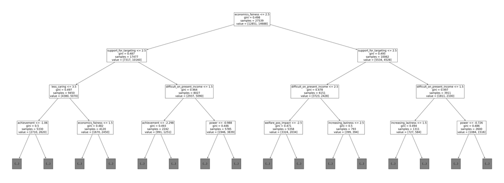

```python
plt.figure(figsize=(55, 20))
plot_tree(tree, feature_names=Xtrain.columns, fontsize=16, max_depth=3)
plt.show()
```

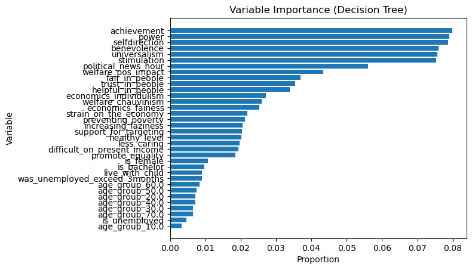

```python
# Create a DataFrame with variable importance
var_imp = pd.DataFrame({'Variable': Xtrain.columns,
                        'Importance': tree.feature_importances_})

# Filter the DataFrame to only include features with positive importance values
var_imp = var_imp[var_imp['Importance'] > 0]

# Sort the DataFrame by importance
var_imp = var_imp.sort_values(by='Importance')

# Plot the variable importance
plt.barh(var_imp['Variable'], var_imp['Importance'])
plt.xlabel('Proportion')
plt.ylabel('Variable')
plt.title('Variable Importance (Decision Tree)')
plt.show()
```

```python
# Fit model
tree2 = DecisionTreeClassifier(max_depth=3, random_state=10)
tree2.fit(Xtrain, ytrain)
tree2.score(Xtest, ytest)
```

```
0.5744371822803195
```

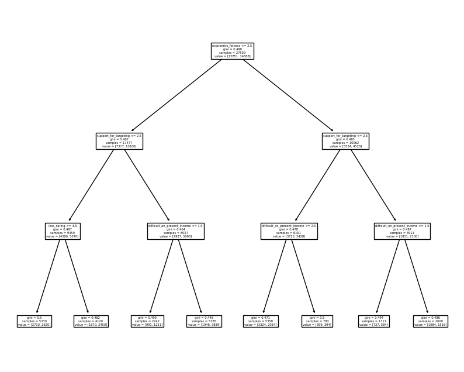

```python
# visualize tree
plt.figure(figsize=(10, 8))
plot_tree(tree2, feature_names = Xtrain.columns)
plt.show()
```

```python
# Calculate feature importances
importance_df = pd.DataFrame({'Feature': Xtest.columns, 'Importance': tree2.feature_importances_})

# Filter out the features where importance is greater than zero
importance_df = importance_df[importance_df['Importance'] > 0]

# Sort the DataFrame by importance in descending order
importance_df = importance_df.sort_values(by='Importance', ascending=False)

# Display the DataFrame
print(importance_df)
```

```
                        Feature  Importance
11            economics_fainess    0.410075
18        support_for_targeting    0.334009
22  difficult_on_present_income    0.163936
16                  less_caring    0.091981
```

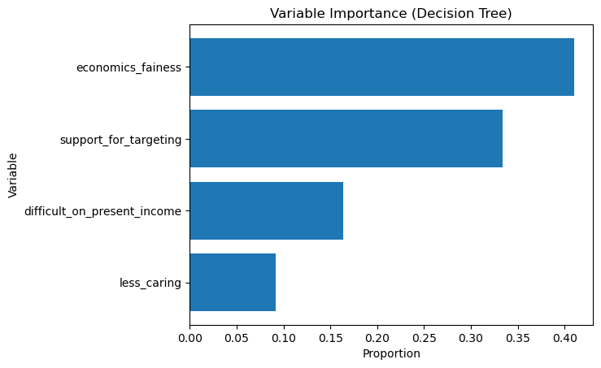

```python
# Create a DataFrame with variable importance
var_imp = pd.DataFrame({'Variable': Xtest.columns,
                        'Importance': tree2.feature_importances_})

# Filter the DataFrame to only include features with positive importance values
var_imp = var_imp[var_imp['Importance'] > 0]

# Sort the DataFrame by importance
var_imp = var_imp.sort_values(by='Importance')

# Plot the variable importance
plt.barh(var_imp['Variable'], var_imp['Importance'])
plt.xlabel('Proportion')
plt.ylabel('Variable')
plt.title('Variable Importance (Decision Tree)')
plt.show()
```

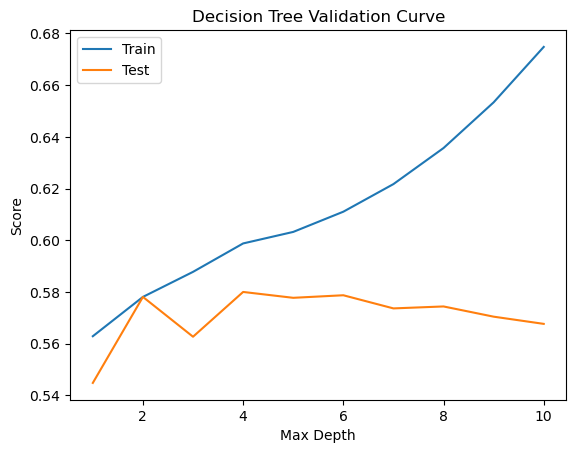

```python
# validation curve

from sklearn.tree import DecisionTreeClassifier
from sklearn.model_selection import validation_curve

# Create a Decision Tree classifier instance
dtc = DecisionTreeClassifier()

# Define the range of max_depth values for the validation curve
depth_range = np.arange(1, 11)  # Max depth values from 1 to 10

# Calculate the validation curve
train_scores, test_scores = validation_curve(dtc, X, ydummy, param_name='max_depth', param_range=depth_range, cv=10)

# Calculate mean scores
train_mean = np.mean(train_scores, axis=1)
test_mean = np.mean(test_scores, axis=1)

# Plot the validation curve
fig1 = plt.figure()
plt.plot(depth_range, train_mean, label='Train')
plt.plot(depth_range, test_mean, label='Test')
plt.xlabel('Max Depth')
plt.ylabel('Score')
plt.title('Decision Tree Validation Curve')
plt.legend()
plt.show()

# Save the plot as an image
fig1.savefig('validation_curve_decision_tree.png')
```

```python
# learning curve
```

```python
# RoC curve
```

```python
# random forest classifier
rfmodel = RandomForestClassifier(max_depth=3, random_state=10)
rfmodel.fit(Xtrain, ytrain)
```

```
RandomForestClassifier(max_depth=3, random_state=10)
```

```python
# random forest mean accuracy
cross_val_score(rfmodel, X, ydummy, cv=5).mean()
```

```
0.5873521584156076
```

```python
# Calculate feature importances
importance_df = pd.DataFrame({'Feature': Xtest.columns, 'Importance': rfmodel.feature_importances_})

# Filter out the features where importance is greater than zero
importance_df = importance_df[importance_df['Importance'] > 0]

# Sort the DataFrame by importance in descending order
importance_df = importance_df.sort_values(by='Importance', ascending=False)

# Display the DataFrame
print(importance_df)
```

```
                          Feature  Importance
18          support_for_targeting    0.204978
11              economics_fainess    0.204814
22    difficult_on_present_income    0.136451
10         economics_individulism    0.065928
15            increasing_laziness    0.063346
4                     achievement    0.054598
0                     benevolence    0.048478
26             welfare_pos_impact    0.047342
16                    less_caring    0.032961
2                   selfdirection    0.025845
3                     stimulation    0.019655
17             welfare_chauvinism    0.018408
12          strain_on_the_economy    0.018322
5                           power    0.014506
```

[output cut: 16 more lines]

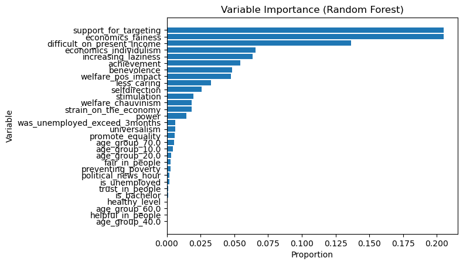

```python
# Create a DataFrame with variable importance
var_imp = pd.DataFrame({'Variable': Xtest.columns,
                        'Importance':  rfmodel.feature_importances_})

# Filter the DataFrame to only include features with positive importance values
var_imp = var_imp[var_imp['Importance'] > 0]

# Sort the DataFrame by importance
var_imp = var_imp.sort_values(by='Importance')

# Plot the variable importance
plt.barh(var_imp['Variable'], var_imp['Importance'])
plt.xlabel('Proportion')
plt.ylabel('Variable')
plt.title('Variable Importance (Random Forest)')
plt.show()
```

```python
from sklearn.ensemble import AdaBoostClassifier
from sklearn.tree import DecisionTreeClassifier

# Create a base estimator
base_estimator = DecisionTreeClassifier(max_depth=3, random_state=10)

# Fit model
ada = AdaBoostClassifier(base_estimator=base_estimator, random_state=10)
ada.fit(Xtrain, ytrain)

# Score model
print(ada.score(Xtest, ytest))

# Calculate feature importances
importance_df = pd.DataFrame({'Feature': Xtest.columns, 'Importance': ada.feature_importances_})

# Filter out the features where importance is greater than zero
importance_df = importance_df[importance_df['Importance'] > 0]

# Sort the DataFrame by importance in descending order
importance_df = importance_df.sort_values(by='Importance', ascending=False)

# Display the DataFrame
print(importance_df)
```

```
0.5940450254175744
                          Feature  Importance
0                     benevolence    0.100753
4                     achievement    0.092782
1                    universalism    0.091585
3                     stimulation    0.089731
5                           power    0.086884
2                   selfdirection    0.073013
6             political_news_hour    0.067721
26             welfare_pos_impact    0.059150
8                  fair_in_people    0.041614
11              economics_fainess    0.029306
9               helpful_in_people    0.028437
18          support_for_targeting    0.025640
19                  healthy_level    0.024164
```

[output cut: 19 more lines]

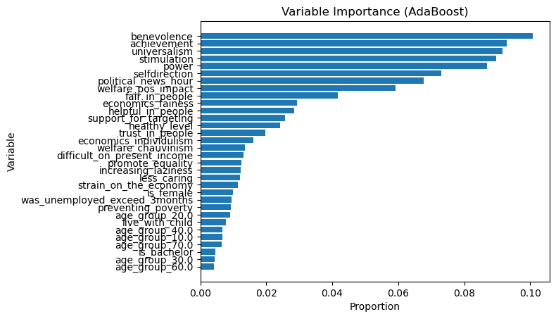

```python
# Create a DataFrame with variable importance
var_imp = pd.DataFrame({'Variable': Xtest.columns,
                        'Importance':  ada.feature_importances_})

# Filter the DataFrame to only include features with positive importance values
var_imp = var_imp[var_imp['Importance'] > 0]

# Sort the DataFrame by importance
var_imp = var_imp.sort_values(by='Importance')

# Plot the variable importance
plt.barh(var_imp['Variable'], var_imp['Importance'])
plt.xlabel('Proportion')
plt.ylabel('Variable')
plt.title('Variable Importance (AdaBoost)')
plt.show()
```

```python
# model comparison
Xtrain, Xtest, ytrain, ytest = train_test_split(X, ydummy, test_size=0.3, random_state=1)

probabilities = {'Decision Tree': tree.fit(Xtrain, ytrain).predict_proba(Xtest),
                 'Random Forest': rfmodel.fit(Xtrain, ytrain).predict_proba(Xtest),
                 'AdaBoost': ada.fit(Xtrain, ytrain).predict_proba(Xtest)}
```

```python
def get_curve_data(ytrue, yprobs, pos_class_label):
    FPR, TPR, thresholds = roc_curve(ytrue, yprobs, pos_label=pos_class_label)
    rates = pd.DataFrame(dict(fpr=FPR, tpr=TPR))
    return {'rates': rates}
```

```python
dt_data = get_curve_data(ytest, probabilities['Decision Tree'][:,1], 1)
rf_data = get_curve_data(ytest, probabilities['Random Forest'][:,1], 1)
ada_data = get_curve_data(ytest, probabilities['AdaBoost'][:,1], 1)
```

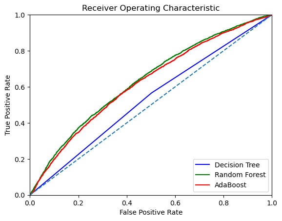

```python
fig_roc = plt.figure()
plt.plot(dt_data['rates'].fpr, dt_data['rates'].tpr, 'blue', label='Decision Tree')
plt.plot(rf_data['rates'].fpr, rf_data['rates'].tpr, 'green', label='Random Forest')
plt.plot(ada_data['rates'].fpr, ada_data['rates'].tpr, 'red', label='AdaBoost')
plt.plot([0, 1], [0, 1],'--')
plt.xlim([0, 1])
plt.ylim([0, 1])
plt.ylabel('True Positive Rate')
plt.xlabel('False Positive Rate')
plt.title('Receiver Operating Characteristic')
plt.legend(loc = 'lower right')
plt.show()
```